# Capstone_Project-Vinay

#### 5.1.4 reports and metrics for logistic model on test data

```python
# calculate the probability for test data set using model created
y_test_pred_prob = log_model.predict(Xc_test)

# predict the test values
y_test_pred = [0 if x < 0.5 else 1 for x in y_test_pred_prob]

# display the classification report
print(classification_report(y_test,y_test_pred))
```

```
              precision    recall  f1-score   support

           0       0.83      0.92      0.87       996
           1       0.74      0.54      0.62       411

    accuracy                           0.81      1407
   macro avg       0.78      0.73      0.75      1407
weighted avg       0.80      0.81      0.80      1407
```

Model created is working with **81% accuray** on test data. So we can conclude that the model is niether over fitting or under fitting

```python
kappa = cohen_kappa_score(y_test, y_test_pred)
kappa
```

```
0.501617852494836
```

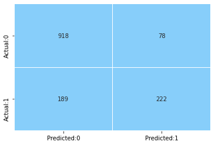

```python
# create Confusion matrix for test data
cm = confusion_matrix(y_test,y_test_pred)

#plot the confussion matrix for test data
con_matrix = pd.DataFrame(cm,columns=['Predicted:0','Predicted:1'],index=['Actual:0','Actual:1'])
sns.heatmap(con_matrix,annot=True,fmt='d',cmap=ListedColormap(['Lightskyblue']),cbar=False,linewidths=0.1)
plt.show()
```

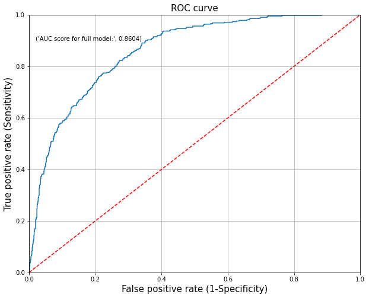

```python
plt.figure(figsize=(10,8))
fpr, tpr, thresholds = roc_curve(y_test,y_test_pred_prob)
plt.plot(fpr,tpr)

plt.xlim([0.0,1.0])
plt.ylim([0.0,1.0])

plt.plot([0,1],[0,1],'r--')

plt.title('ROC curve', fontsize = 15)
plt.xlabel('False positive rate (1-Specificity)', fontsize = 15)
plt.ylabel('True positive rate (Sensitivity)', fontsize = 15)

plt.text(x=0.02,y=0.9,s=('AUC score for full model:',round(metrics.roc_auc_score(y_test,y_test_pred_prob),4)))


plt.grid(True)
```

From the above plot, we can see that our model (logistic_model) is away from the red dotted line; with the AUC score 0.8604 on test data.

### ii. Descision Tree

|  | **import libraries** |
| --- | --- |

```python
# import decision tree classifier from sklear tream module
from sklearn.tree import DecisionTreeClassifier
from sklearn import tree
```

#### model

```python
# Intantiate DecisionTreeClassifier
# using entropy as criteria
# chosing random state as 10
dt = DecisionTreeClassifier(criterion = 'entropy', random_state = 10)

# fit model on train data set
dt_model = dt.fit(X_train,y_train)
```

#### reports and metrics for decision tree model on train data

```python
# predict target values using model built
y_train_prob = dt_model.predict(X_train)

y_train_pred = [0 if x< 0.5 else 1 for x in y_train_prob]

# display the classification report
print(classification_report(y_train,y_train_pred))
```

```
              precision    recall  f1-score   support

           0       1.00      1.00      1.00      4167
           1       1.00      0.99      1.00      1458

    accuracy                           1.00      5625
   macro avg       1.00      1.00      1.00      5625
weighted avg       1.00      1.00      1.00      5625
```

Model is working with **100% accuracy** on train data set

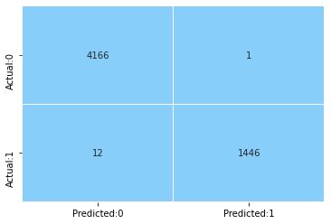

```python
cm = confusion_matrix(y_train,y_train_pred)
con_matrix = pd.DataFrame(cm,columns=['Predicted:0','Predicted:1'],index=['Actual:0','Actual:1'])
sns.heatmap(con_matrix,annot=True,fmt='d',cmap=ListedColormap(['Lightskyblue']),cbar=False,linewidths=0.1)
plt.show()
```

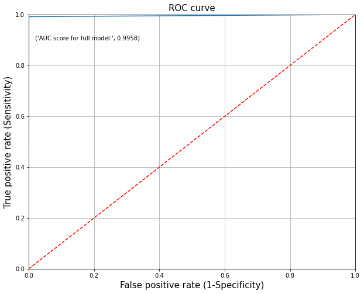

```python
plt.figure(figsize=(10,8))
fpr, tpr, thresholds = roc_curve(y_train,y_train_prob)
plt.plot(fpr,tpr)

plt.xlim([0.0,1.0])
plt.ylim([0.0,1.0])

plt.plot([0,1],[0,1],'r--')

plt.title('ROC curve', fontsize = 15)
plt.xlabel('False positive rate (1-Specificity)', fontsize = 15)
plt.ylabel('True positive rate (Sensitivity)', fontsize = 15)

plt.text(x=0.02,y=0.9,s=('AUC score for full model:',round(metrics.roc_auc_score(y_train,y_train_prob),4)))


plt.grid(True)
```

From the above plot, we can see that our classifier (decision_model) is away from the red dotted line; with the AUC score 0.9958.

#### reports and metrics for Decision Tree on test data

```python
# predict target values using model built
y_test_prob = dt_model.predict(X_test)

y_test_pred = [0 if x<0.5 else 1 for x in y_test_prob]

# display the classification report
print(classification_report(y_test,y_test_pred))
```

```
              precision    recall  f1-score   support

           0       0.80      0.82      0.81       996
           1       0.54      0.50      0.52       411

    accuracy                           0.73      1407
   macro avg       0.67      0.66      0.67      1407
weighted avg       0.73      0.73      0.73      1407
```

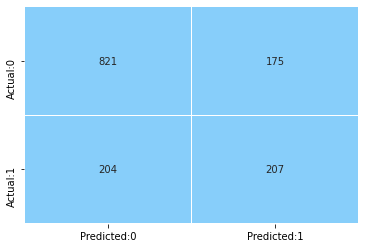

```python
cm = confusion_matrix(y_test,y_test_pred)
con_matrix = pd.DataFrame(cm,columns=['Predicted:0','Predicted:1'],index=['Actual:0','Actual:1'])
sns.heatmap(con_matrix,annot=True,fmt='d',cmap=ListedColormap(['Lightskyblue']),cbar=False,linewidths=0.1)
plt.show()
```

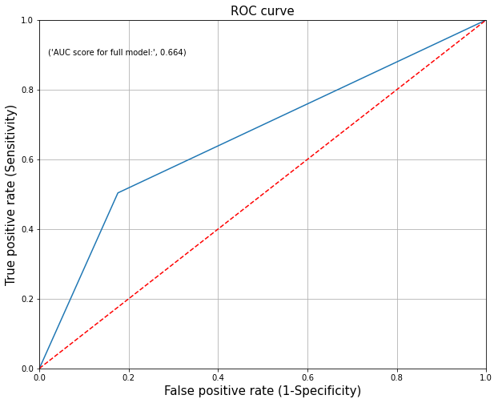

```python
plt.figure(figsize=(10,8))
fpr, tpr, thresholds = roc_curve(y_test,y_test_prob)
plt.plot(fpr,tpr)

plt.xlim([0.0,1.0])
plt.ylim([0.0,1.0])

plt.plot([0,1],[0,1],'r--')

plt.title('ROC curve', fontsize = 15)
plt.xlabel('False positive rate (1-Specificity)', fontsize = 15)
plt.ylabel('True positive rate (Sensitivity)', fontsize = 15)

plt.text(x=0.02,y=0.9,s=('AUC score for full model:',round(metrics.roc_auc_score(y_test,y_test_prob),4)))


plt.grid(True)
```

##### Define a function to evaluate Models

```python
# create an empty dataframe to store the scores for various algorithms
report_card = pd.DataFrame(columns=['Model Name', 'AUC Score', 'Precision Score', 'Recall Score',
                                       'Accuracy Score', 'Kappa Score', 'f1-score'])

# append the result table for all performance scores
# performance measures considered for model comparision are 'AUC Score', 'Precision Score', 'Recall Score','Accuracy Score',
# 'Kappa Score', and 'f1-score'
# compile the required information in a user defined function
def Performance_report(model, Model_name):

    # let 'y_pred_prob' be the predicted values of y
    y_pred= model.predict(X_test)


    # assign 'score_card' as global variable
    global report_card

    # append the results to the dataframe 'score_card'
    # 'ignore_index = True' do not consider the index labels
    report_card = report_card.append({'Model Name': Model_name,
                                    'AUC Score' : metrics.roc_auc_score(y_test, y_pred),
                                    'Precision Score': metrics.precision_score(y_test, y_pred),
                                    'Recall Score': metrics.recall_score(y_test, y_pred),
                                    'Accuracy Score': metrics.accuracy_score(y_test, y_pred),
                                    'Kappa Score':metrics.cohen_kappa_score(y_test, y_pred),
                                    'f1-score': metrics.f1_score(y_test, y_pred)},
                                    ignore_index = True)
```

```python
Performance_report(dt_model, 'Basic Decision Tree')
report_card
```

|  | Model Name | AUC Score | Precision Score | Recall Score | Accuracy Score | Kappa Score | f1-score |
| --- | --- | --- | --- | --- | --- | --- | --- |
| 0 | Basic Decision Tree | 0.663973 | 0.541885 | 0.503650 | 0.730633 | 0.334886 | 0.522068 |

```python
report_card.append({'Model Name': 'Basic Logistic Model -0.5 cuttoff',
                                    'AUC Score' : 0.8604,
                                    'Precision Score': 0.74 ,
                                    'Recall Score': 0.54,
                                    'Accuracy Score': 0.81,
                                    'Kappa Score': 0.50,
                                    'f1-score': 0.62},
                                    ignore_index = True)
```

|  | Model Name | AUC Score | Precision Score | Recall Score | Accuracy Score | Kappa Score | f1-score |
| --- | --- | --- | --- | --- | --- | --- | --- |
| 0 | Basic Decision Tree | 0.663973 | 0.541885 | 0.503650 | 0.730633 | 0.334886 | 0.522068 |
| 1 | Basic Logistic Model -0.5 cuttoff | 0.860400 | 0.740000 | 0.540000 | 0.810000 | 0.500000 | 0.620000 |

## Hyper Parameter Tuning for Decision Tree Model

|  | **import libraries** |
| --- | --- |

```python
from sklearn.model_selection import GridSearchCV
```

```python
tuned_paramaters = [{'criterion': ['entropy', 'gini'],
                     'max_depth': range(2, 10),
                     'max_features': ["sqrt", "log2"],
                     'min_samples_split': range(2,10),
                     'min_samples_leaf': range(1,10),
                     'max_leaf_nodes': range(1, 10)}]
```

```python
DT = DecisionTreeClassifier()
gscv_dt = GridSearchCV(estimator=DT, param_grid=tuned_paramaters, cv=5)
```

```python
gscv_dt_model = gscv_dt.fit(X_train, y_train)
```

```python
gscv_dt_model.best_params_
```

```
{'criterion': 'gini',
 'max_depth': 6,
 'max_features': 'log2',
 'max_leaf_nodes': 9,
 'min_samples_leaf': 8,
 'min_samples_split': 8}
```

```python
dt_tuned = DecisionTreeClassifier(criterion = 'gini',
 max_depth = 7,
 max_features = 'log2',
 max_leaf_nodes = 7,
 min_samples_leaf = 8,
 min_samples_split = 3, random_state=10)
```

```python
dt_tuned_model = dt_tuned.fit(X_train, y_train)
```

### For Train

```python
# predict target values using model built
y_train_prob = dt_tuned_model.predict(X_train)

y_train_pred = [0 if x<0.5 else 1 for x in y_train_prob]

# display the classification report
print(classification_report(y_train,y_train_pred))
```

```
              precision    recall  f1-score   support

           0       0.83      0.90      0.87      4167
           1       0.64      0.49      0.55      1458

    accuracy                           0.80      5625
   macro avg       0.74      0.70      0.71      5625
weighted avg       0.78      0.80      0.79      5625
```

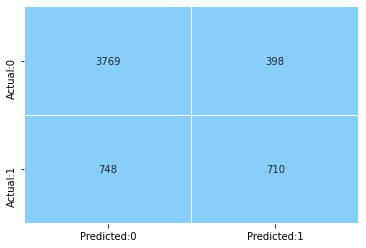

```python
cm = confusion_matrix(y_train,y_train_pred)
con_matrix = pd.DataFrame(cm,columns=['Predicted:0','Predicted:1'],index=['Actual:0','Actual:1'])
sns.heatmap(con_matrix,annot=True,fmt='d',cmap=ListedColormap(['Lightskyblue']),cbar=False,linewidths=0.1)
plt.show()
```

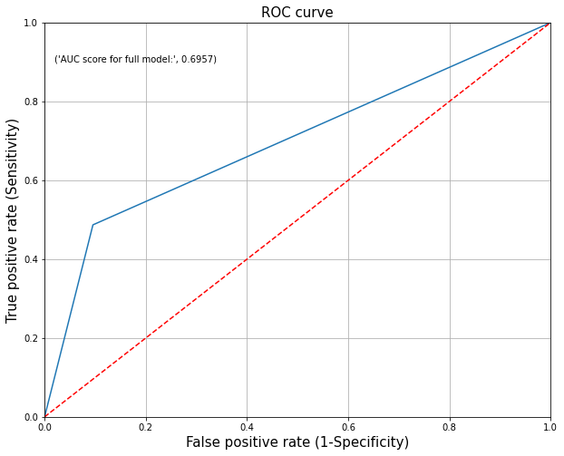

```python
plt.figure(figsize=(10,8))
fpr, tpr, thresholds = roc_curve(y_train,y_train_prob)
plt.plot(fpr,tpr)

plt.xlim([0.0,1.0])
plt.ylim([0.0,1.0])

plt.plot([0,1],[0,1],'r--')

plt.title('ROC curve', fontsize = 15)
plt.xlabel('False positive rate (1-Specificity)', fontsize = 15)
plt.ylabel('True positive rate (Sensitivity)', fontsize = 15)

plt.text(x=0.02,y=0.9,s=('AUC score for full model:',round(metrics.roc_auc_score(y_train,y_train_prob),4)))


plt.grid(True)
```

### For Test

```python
# predict target values using model built
y_test_prob = dt_tuned_model.predict(X_test)

y_test_pred = [0 if x<0.5 else 1 for x in y_test_prob]

# display the classification report
print(classification_report(y_test,y_test_pred))
```

```
              precision    recall  f1-score   support

           0       0.82      0.91      0.86       996
           1       0.71      0.50      0.59       411

    accuracy                           0.79      1407
   macro avg       0.76      0.71      0.73      1407
weighted avg       0.78      0.79      0.78      1407
```

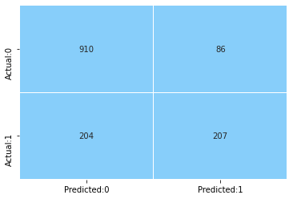

```python
cm = confusion_matrix(y_test,y_test_pred)
con_matrix = pd.DataFrame(cm,columns=['Predicted:0','Predicted:1'],index=['Actual:0','Actual:1'])
sns.heatmap(con_matrix,annot=True,fmt='d',cmap=ListedColormap(['Lightskyblue']),cbar=False,linewidths=0.1)
plt.show()
```

```python
Performance_report(dt_tuned_model, ' Tuned Decision Tree')
report_card
```

|  | Model Name | AUC Score | Precision Score | Recall Score | Accuracy Score | Kappa Score | f1-score |
| --- | --- | --- | --- | --- | --- | --- | --- |
| 0 | Basic Decision Tree | 0.663973 | 0.541885 | 0.503650 | 0.730633 | 0.334886 | 0.522068 |
| 1 | Tuned Decision Tree | 0.708652 | 0.706485 | 0.503650 | 0.793888 | 0.455729 | 0.588068 |

### iii. Random Forest

|  | **import libraries** |
| --- | --- |

```python
from sklearn.ensemble import RandomForestClassifier
```

#### model building

```python
#instantiate RandomForestClassifier
# chosing random state value as 10
rf = RandomForestClassifier(random_state = 10)

# fit the model using train data set
rf_model = rf.fit(X_train,y_train)
```

```python
# predict target values using model built on train data
y_train_prob = rf_model.predict(X_train)

y_train_pred = [0 if x<0.5 else 1 for x in y_train_prob]

# display the classification report
print(classification_report(y_train,y_train_pred))
```

```
              precision    recall  f1-score   support

           0       1.00      1.00      1.00      4167
           1       1.00      0.99      1.00      1458

    accuracy                           1.00      5625
   macro avg       1.00      1.00      1.00      5625
weighted avg       1.00      1.00      1.00      5625
```

Model is working with **100% accuracy** on train data

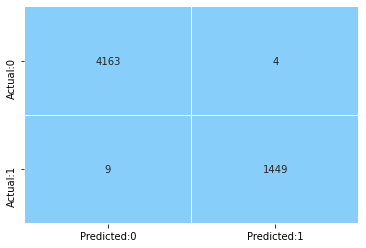

```python
cm = confusion_matrix(y_train,y_train_pred)
con_matrix = pd.DataFrame(cm,columns=['Predicted:0','Predicted:1'],index=['Actual:0','Actual:1'])
sns.heatmap(con_matrix,annot=True,fmt='d',cmap=ListedColormap(['Lightskyblue']),cbar=False,linewidths=0.1)
plt.show()
```

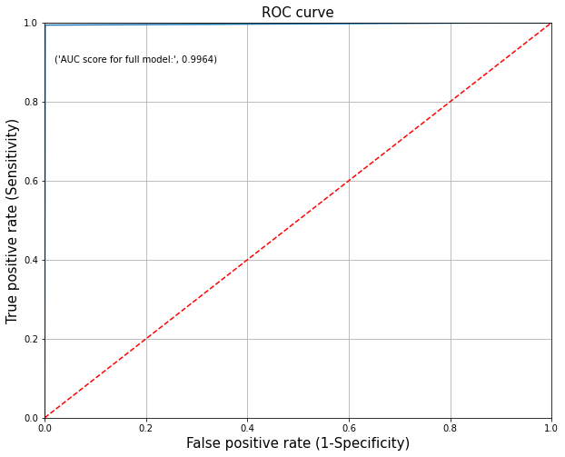

```python
plt.figure(figsize=(10,8))
fpr, tpr, thresholds = roc_curve(y_train,y_train_pred)
plt.plot(fpr,tpr)

plt.xlim([0.0,1.0])
plt.ylim([0.0,1.0])

plt.plot([0,1],[0,1],'r--')

plt.title('ROC curve', fontsize = 15)
plt.xlabel('False positive rate (1-Specificity)', fontsize = 15)
plt.ylabel('True positive rate (Sensitivity)', fontsize = 15)

plt.text(x=0.02,y=0.9,s=('AUC score for full model:',round(metrics.roc_auc_score(y_train,y_train_pred),4)))


plt.grid(True)
```

From the above plot, we can see that our random forest classifier (rf_model) is away from the red dotted line; with the AUC score 0.9964 on train data set.

```python
# predict target values using model built on test data
y_test_prob = rf_model.predict(X_test)

y_test_pred = [0 if x<0.5 else 1 for x in y_test_prob]

# display the classification report
print(classification_report(y_test,y_test_pred))
```

```
              precision    recall  f1-score   support

           0       0.81      0.91      0.86       996
           1       0.69      0.47      0.56       411

    accuracy                           0.78      1407
   macro avg       0.75      0.69      0.71      1407
weighted avg       0.77      0.78      0.77      1407
```

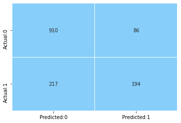

```python
cm = confusion_matrix(y_test,y_test_pred)
con_matrix = pd.DataFrame(cm,columns=['Predicted:0','Predicted:1'],index=['Actual:0','Actual:1'])
sns.heatmap(con_matrix,annot=True,fmt='d',cmap=ListedColormap(['Lightskyblue']),cbar=False,linewidths=0.1)
plt.show()
```

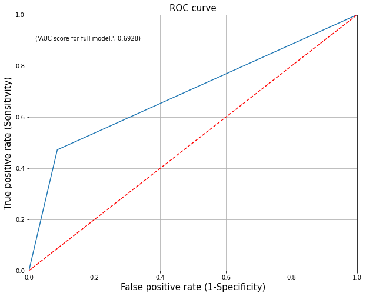

```python
plt.figure(figsize=(10,8))
fpr, tpr, thresholds = roc_curve(y_test,y_test_pred)
plt.plot(fpr,tpr)

plt.xlim([0.0,1.0])
plt.ylim([0.0,1.0])

plt.plot([0,1],[0,1],'r--')

plt.title('ROC curve', fontsize = 15)
plt.xlabel('False positive rate (1-Specificity)', fontsize = 15)
plt.ylabel('True positive rate (Sensitivity)', fontsize = 15)

plt.text(x=0.02,y=0.9,s=('AUC score for full model:',round(metrics.roc_auc_score(y_test,y_test_pred),4)))


plt.grid(True)
```

```python
Performance_report(rf_model, 'Basic RandomForest Tree')
report_card
```

|  | Model Name | AUC Score | Precision Score | Recall Score | Accuracy Score | Kappa Score | f1-score |
| --- | --- | --- | --- | --- | --- | --- | --- |
| 0 | Basic Decision Tree | 0.663973 | 0.541885 | 0.503650 | 0.730633 | 0.334886 | 0.522068 |
| 1 | Tuned Decision Tree | 0.708652 | 0.706485 | 0.503650 | 0.793888 | 0.455729 | 0.588068 |
| 2 | Basic RandomForest Tree | 0.692837 | 0.692857 | 0.472019 | 0.784648 | 0.425503 | 0.561505 |

## Grid Search for Random Forest

```python
tuned_paramaters_rf = [{'criterion': ['entropy', 'gini'],
                     'n_estimators': [10, 30, 50, 70, 90],
                     'max_depth': [10, 15, 20],
                     'max_features': ['sqrt', 'log2'],
                     'min_samples_split': [2, 5, 8, 11],
                     'min_samples_leaf': [1, 5, 9],
                     'max_leaf_nodes': [2, 5, 8, 11]}]
```

```python
RF = RandomForestClassifier()
gscv_rf = GridSearchCV(estimator=RF, param_grid=tuned_paramaters_rf, cv=5)
```

```python
gscv_rf_model = gscv_rf.fit(X_train, y_train)
```

```python
gscv_rf_model.best_params_
```

```
{'criterion': 'gini',
 'max_depth': 20,
 'max_features': 'sqrt',
 'max_leaf_nodes': 11,
 'min_samples_leaf': 1,
 'min_samples_split': 11,
 'n_estimators': 10}
```

```python
rf_tuned = RandomForestClassifier(criterion = 'entropy',
 max_depth = 15,
 max_features = 'sqrt',
 max_leaf_nodes = 11,
 min_samples_leaf = 1,
 min_samples_split = 5, n_estimators = 30, random_state=10)
```

```python
rf_tuned_model = rf_tuned.fit(X_train, y_train)
```

### For Train

```python
# predict target values using model built
y_train_prob = rf_tuned_model.predict(X_train)

y_train_pred = [0 if x<0.5 else 1 for x in y_train_prob]

# display the classification report
print(classification_report(y_train,y_train_pred))
```

```
              precision    recall  f1-score   support

           0       0.81      0.95      0.87      4167
           1       0.71      0.37      0.49      1458

    accuracy                           0.80      5625
   macro avg       0.76      0.66      0.68      5625
weighted avg       0.78      0.80      0.77      5625
```

### For Test

```python
# predict target values using model built
y_test_prob = rf_tuned_model.predict(X_test)

y_test_pred = [0 if x<0.5 else 1 for x in y_test_prob]

# display the classification report
print(classification_report(y_test,y_test_pred))
```

```
              precision    recall  f1-score   support

           0       0.79      0.95      0.86       996
           1       0.77      0.40      0.53       411

    accuracy                           0.79      1407
   macro avg       0.78      0.68      0.70      1407
weighted avg       0.79      0.79      0.77      1407
```

```python
Performance_report(rf_tuned_model, 'Tuned Random Forest Tree')
report_card
```

[output not shown]

### iv. K Nearest Neighbors (KNN)

KNN is a classification machine learning algorithm used to identify the class of the observation. This algorithm search for `K` nearest points to determine the class of an observation. To identify the nearest points, it considers the distance metrics like `Euclidean`, `Manhattan`, `Chebyshev`, `Hamming`, and so on.

|  | **import libraries** |
| --- | --- |

```python
from sklearn.neighbors import KNeighborsClassifier
```

#### model

```python
# instantiate the 'KNeighborsClassifier'
# n_neighnors: number of neighbors to consider
# default metric is minkowski, and with p=3 it is equivalent to the euclidean metric
knn = KNeighborsClassifier(n_neighbors = 3)

# fit the model using fit() on train data
knn_model = knn.fit(X_train,y_train)
```

#### reports and metrics for train data

```python
y_train_pred = knn_model.predict(X_train)
print(classification_report(y_train,y_train_pred))
```

```
              precision    recall  f1-score   support

           0       0.90      0.92      0.91      4167
           1       0.76      0.69      0.73      1458

    accuracy                           0.86      5625
   macro avg       0.83      0.81      0.82      5625
weighted avg       0.86      0.86      0.86      5625
```

Accuracy of KNN model on train data set is **86%**

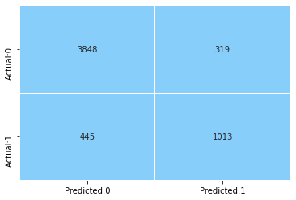

```python
cm = confusion_matrix(y_train,y_train_pred)
con_matrix = pd.DataFrame(cm,columns=['Predicted:0','Predicted:1'],index=['Actual:0','Actual:1'])
sns.heatmap(con_matrix,annot=True,fmt='d',cmap=ListedColormap(['Lightskyblue']),cbar=False,linewidths=0.1)
plt.show()
```

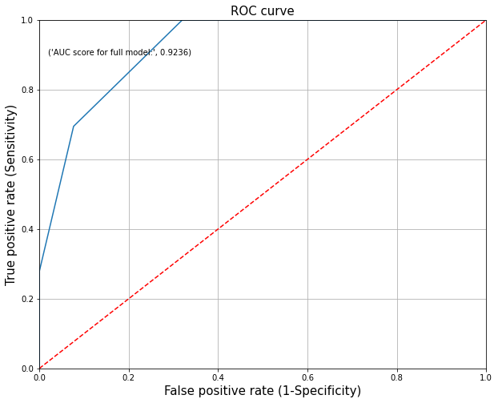

```python
y_train_pro = knn_model.predict_proba(X_train)[:,1]
plt.figure(figsize=(10,8))
fpr, tpr, thresholds = roc_curve(y_train,y_train_pro)
plt.plot(fpr,tpr)

plt.xlim([0.0,1.0])
plt.ylim([0.0,1.0])

plt.plot([0,1],[0,1],'r--')

plt.title('ROC curve', fontsize = 15)
plt.xlabel('False positive rate (1-Specificity)', fontsize = 15)
plt.ylabel('True positive rate (Sensitivity)', fontsize = 15)

plt.text(x=0.02,y=0.9,s=('AUC score for full model:',round(metrics.roc_auc_score(y_train,y_train_pro),4)))


plt.grid(True)
```

#### reports and metrics for test data

```python
y_test_pred = knn_model.predict(X_test)
print(classification_report(y_test,y_test_pred))
```

```
              precision    recall  f1-score   support

           0       0.79      0.84      0.82       996
           1       0.55      0.47      0.51       411

    accuracy                           0.73      1407
   macro avg       0.67      0.66      0.66      1407
weighted avg       0.72      0.73      0.73      1407
```

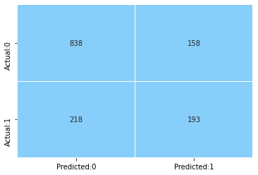

```python
cm = confusion_matrix(y_test,y_test_pred)
con_matrix = pd.DataFrame(cm,columns=['Predicted:0','Predicted:1'],index=['Actual:0','Actual:1'])
sns.heatmap(con_matrix,annot=True,fmt='d',cmap=ListedColormap(['Lightskyblue']),cbar=False,linewidths=0.1)
plt.show()
```

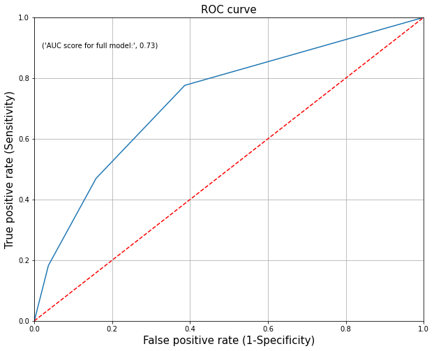

```python
y_test_pro = knn_model.predict_proba(X_test)[:,1]
plt.figure(figsize=(10,8))
fpr, tpr, thresholds = roc_curve(y_test,y_test_pro)
plt.plot(fpr,tpr)

plt.xlim([0.0,1.0])
plt.ylim([0.0,1.0])

plt.plot([0,1],[0,1],'r--')

plt.title('ROC curve', fontsize = 15)
plt.xlabel('False positive rate (1-Specificity)', fontsize = 15)
plt.ylabel('True positive rate (Sensitivity)', fontsize = 15)

plt.text(x=0.02,y=0.9,s=('AUC score for full model:',round(metrics.roc_auc_score(y_test,y_test_pro),4)))

plt.grid(True)
```

```python
Performance_report(knn_model, 'Basic KNN Tree')
report_card
```

|  | Model Name | AUC Score | Precision Score | Recall Score | Accuracy Score | Kappa Score | f1-score |
| --- | --- | --- | --- | --- | --- | --- | --- |
| 0 | Basic Decision Tree | 0.663973 | 0.541885 | 0.503650 | 0.730633 | 0.334886 | 0.522068 |
| 1 | Tuned Decision Tree | 0.708652 | 0.706485 | 0.503650 | 0.793888 | 0.455729 | 0.588068 |
| 2 | Basic RandomForest Tree | 0.692837 | 0.692857 | 0.472019 | 0.784648 | 0.425503 | 0.561505 |
| 3 | Basic KNN Tree | 0.655476 | 0.549858 | 0.469586 | 0.732765 | 0.324880 | 0.506562 |

### Grid Search for optimal Value of K

|  | **import libraries** |
| --- | --- |

```python
from sklearn.model_selection import GridSearchCV
```

```python
# create a dictionary with hyperparameters and its values
# n_neighnors: number of neighbors to consider
# usually, we consider the odd value of 'n_neighnors' to avoid the equal number of nearest points with more than one class
# pass the different distance metrics to the parameter, 'metric'
tuned_paramaters = {'n_neighbors': np.arange(1, 25, 2),
                   'metric': ['hamming','euclidean','manhattan','Chebyshev']}

# instantiate the 'KNeighborsClassifier'
knn_classification = KNeighborsClassifier()

# use GridSearchCV() to find the optimal value of the hyperparameters
# estimator: pass the knn model
# param_grid: pass the dictionary with hyperparameters and its values
# cv: number of folds in k-fold i.e. here cv = 5
# scoring: pass the scoring parameter 'accuracy'
knn_grid = GridSearchCV(estimator = knn_classification,
                        param_grid = tuned_paramaters,
                        cv = 5,
                        scoring = 'accuracy')

# fit the model on X_train and y_train using fit()
knn_grid.fit(X_train, y_train)

# get the best parameters
print('Best parameters for KNN Classifier: ', knn_grid.best_params_, '\n')
```

```
Best parameters for KNN Classifier:  {'metric': 'manhattan', 'n_neighbors': 19}
```

```python
from sklearn.model_selection import cross_val_score
```

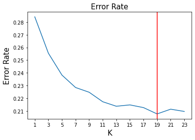

```python
# consider an empty list to store error rate
error_rate = []

# use for loop to build a knn model for each K
for i in np.arange(1,25,2):

    # setup a knn classifier with k neighbors
    # use the 'euclidean' metric
    knn = KNeighborsClassifier(i, metric = 'manhattan')

    # fit the model using 'cross_val_score'
    # pass the knn model as 'estimator'
    # use 5-fold cross validation
    score = cross_val_score(knn, X_train, y_train, cv = 5)

    # calculate the mean score
    score = score.mean()

    # compute error rate
    error_rate.append(1 - score)

# plot the error_rate for different values of K
plt.plot(range(1,25,2), error_rate)


plt.title('Error Rate', fontsize = 15)
plt.xlabel('K', fontsize = 15)
plt.ylabel('Error Rate', fontsize = 15)

# set the x-axis labels
plt.xticks(np.arange(1, 25, step = 2))

# plot a vertical line across the minimum error rate
plt.axvline(x = 19, color = 'red')

# display the plot
plt.show()
```

```python
# instantiate the 'KNeighborsClassifier'
# n_neighnors: number of neighbors to consider
# default metric is minkowski, and with p=3 it is equivalent to the euclidean metric
knn = KNeighborsClassifier(n_neighbors = 19, metric='manhattan')

# fit the model using fit() on train data
knn_model = knn.fit(X_train,y_train)
```

```python
y_train_pred = knn_model.predict(X_train)
print(classification_report(y_train,y_train_pred))
```

```
              precision    recall  f1-score   support

           0       0.86      0.89      0.87      4167
           1       0.65      0.58      0.62      1458

    accuracy                           0.81      5625
   macro avg       0.75      0.74      0.74      5625
weighted avg       0.81      0.81      0.81      5625
```

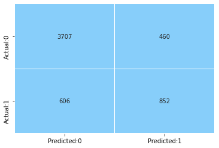

```python
cm = confusion_matrix(y_train,y_train_pred)
con_matrix = pd.DataFrame(cm,columns=['Predicted:0','Predicted:1'],index=['Actual:0','Actual:1'])
sns.heatmap(con_matrix,annot=True,fmt='d',cmap=ListedColormap(['Lightskyblue']),cbar=False,linewidths=0.1)
plt.show()
```

```python
y_test_pred = knn_model.predict(X_test)
print(classification_report(y_test,y_test_pred))
```

```
              precision    recall  f1-score   support

           0       0.83      0.88      0.85       996
           1       0.66      0.56      0.60       411

    accuracy                           0.79      1407
   macro avg       0.74      0.72      0.73      1407
weighted avg       0.78      0.79      0.78      1407
```

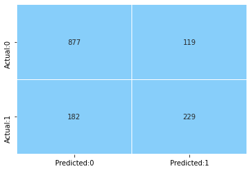

```python
cm = confusion_matrix(y_test,y_test_pred)
con_matrix = pd.DataFrame(cm,columns=['Predicted:0','Predicted:1'],index=['Actual:0','Actual:1'])
sns.heatmap(con_matrix,annot=True,fmt='d',cmap=ListedColormap(['Lightskyblue']),cbar=False,linewidths=0.1)
plt.show()
```

```python
Performance_report(knn_model, 'Tuned KNN Tree')
report_card
```

|  | Model Name | AUC Score | Precision Score | Recall Score | Accuracy Score | Kappa Score | f1-score |
| --- | --- | --- | --- | --- | --- | --- | --- |
| 0 | Basic Decision Tree | 0.663973 | 0.541885 | 0.503650 | 0.730633 | 0.334886 | 0.522068 |
| 1 | Tuned Decision Tree | 0.708652 | 0.706485 | 0.503650 | 0.793888 | 0.455729 | 0.588068 |
| 2 | Basic RandomForest Tree | 0.692837 | 0.692857 | 0.472019 | 0.784648 | 0.425503 | 0.561505 |
| 3 | Basic KNN Tree | 0.655476 | 0.549858 | 0.469586 | 0.732765 | 0.324880 | 0.506562 |
| 4 | Tuned Random Forest Tree | 0.675630 | 0.767442 | 0.401460 | 0.789623 | 0.408464 | 0.527157 |
| 5 | Tuned KNN Tree | 0.718850 | 0.658046 | 0.557178 | 0.786070 | 0.458332 | 0.603426 |

### v.Naive Bayes:

It uses a `Bayes' Theorem` with the assumption of independence of predictor variables. The sklearn library provides different naive bayes classifiers, as `GaussianNB`, `MultinomialNB` and so on.

|  | **import libraries** |
| --- | --- |

```python
from sklearn.naive_bayes import GaussianNB
```

#### model buliding

```python
# instantiate the 'GaussianNB'
gnb = GaussianNB()

# fit the model using fit() on train data
gnb_model = gnb.fit(X_train,y_train)
```

#### reports and metrics on Train data

```python
y_train_pred = gnb_model.predict(X_train)
print(classification_report(y_train,y_train_pred))
```

```
              precision    recall  f1-score   support

           0       0.90      0.74      0.81      4167
           1       0.51      0.77      0.61      1458

    accuracy                           0.75      5625
   macro avg       0.70      0.75      0.71      5625
weighted avg       0.80      0.75      0.76      5625
```

Accuracy of Naive bayes model on train data set is **75%**.

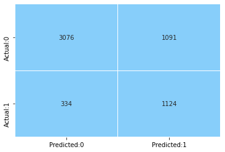

```python
cm = confusion_matrix(y_train,y_train_pred)
con_matrix = pd.DataFrame(cm,columns=['Predicted:0','Predicted:1'],index=['Actual:0','Actual:1'])
sns.heatmap(con_matrix,annot=True,fmt='d',cmap=ListedColormap(['Lightskyblue']),cbar=False,linewidths=0.1)
plt.show()
```

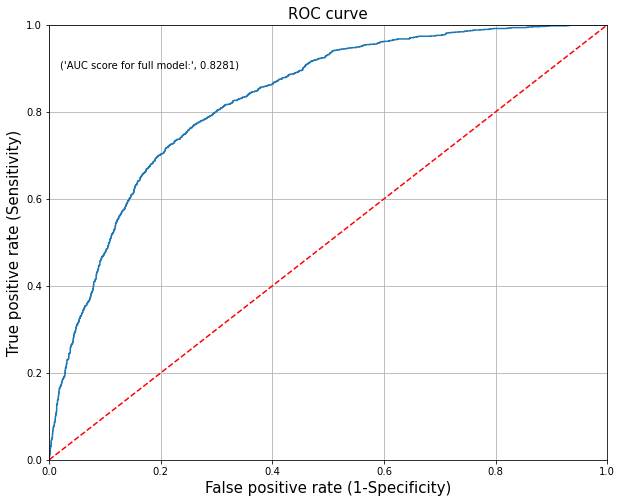

```python
y_train_prob = gnb_model.predict_proba(X_train)[:,1]

plt.figure(figsize=(10,8))
fpr, tpr, thresholds = roc_curve(y_train,y_train_prob)
plt.plot(fpr,tpr)

plt.xlim([0.0,1.0])
plt.ylim([0.0,1.0])

plt.plot([0,1],[0,1],'r--')

plt.title('ROC curve', fontsize = 15)
plt.xlabel('False positive rate (1-Specificity)', fontsize = 15)
plt.ylabel('True positive rate (Sensitivity)', fontsize = 15)

plt.text(x=0.02,y=0.9,s=('AUC score for full model:',round(metrics.roc_auc_score(y_train,y_train_prob),4)))


plt.grid(True)
```

Algorithms like Naive Bayes and tree based algorithms do not need feature scaling or normalization. Performing a features scaling in these algorithms may not have much effect.  
From the above plot, we can see that our classifier (gnb_model) is away from the red dotted line; with the AUC score 0.8281.

#### reports and metrics on test data

```python
y_test_pred = gnb_model.predict(X_test)
print(classification_report(y_test,y_test_pred))
```

```
              precision    recall  f1-score   support

           0       0.89      0.77      0.83       996
           1       0.58      0.77      0.66       411

    accuracy                           0.77      1407
   macro avg       0.74      0.77      0.74      1407
weighted avg       0.80      0.77      0.78      1407
```

Accuracy of Naive bayes model on test data set is **77%**.  
As the accuracy of train data is almost same as test data, the model is neither overfit nor under fit.

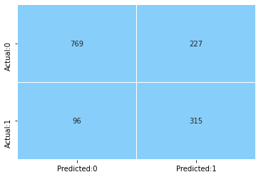

```python
cm = confusion_matrix(y_test,y_test_pred)
con_matrix = pd.DataFrame(cm,columns=['Predicted:0','Predicted:1'],index=['Actual:0','Actual:1'])
sns.heatmap(con_matrix,annot=True,fmt='d',cmap=ListedColormap(['Lightskyblue']),cbar=False,linewidths=0.1)
plt.show()
```

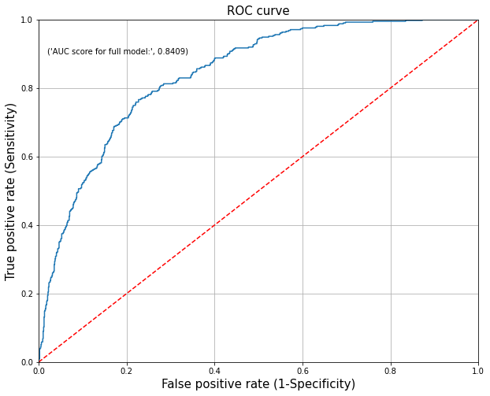

```python
y_test_prob = gnb_model.predict_proba(X_test)[:,1]

plt.figure(figsize=(10,8))
fpr, tpr, thresholds = roc_curve(y_test,y_test_prob)
plt.plot(fpr,tpr)

plt.xlim([0.0,1.0])
plt.ylim([0.0,1.0])

plt.plot([0,1],[0,1],'r--')

plt.title('ROC curve', fontsize = 15)
plt.xlabel('False positive rate (1-Specificity)', fontsize = 15)
plt.ylabel('True positive rate (Sensitivity)', fontsize = 15)

plt.text(x=0.02,y=0.9,s=('AUC score for full model:',round(metrics.roc_auc_score(y_test,y_test_prob),4)))


plt.grid(True)
```

From the above plot, we can see that our classifier (gnb_model) is away from the red dotted line; with the AUC score 0.8409.

```python
Performance_report(gnb_model, 'Basic Navie Bayes Tree')
report_card
```

|  | Model Name | AUC Score | Precision Score | Recall Score | Accuracy Score | Kappa Score | f1-score |
| --- | --- | --- | --- | --- | --- | --- | --- |
| 0 | Basic Decision Tree | 0.663973 | 0.541885 | 0.503650 | 0.730633 | 0.334886 | 0.522068 |
| 1 | Tuned Decision Tree | 0.708652 | 0.706485 | 0.503650 | 0.793888 | 0.455729 | 0.588068 |
| 2 | Basic RandomForest Tree | 0.692837 | 0.692857 | 0.472019 | 0.784648 | 0.425503 | 0.561505 |
| 3 | Basic KNN Tree | 0.655476 | 0.549858 | 0.469586 | 0.732765 | 0.324880 | 0.506562 |
| 4 | Tuned Random Forest Tree | 0.675630 | 0.767442 | 0.401460 | 0.789623 | 0.408464 | 0.527157 |
| 5 | Tuned KNN Tree | 0.718850 | 0.658046 | 0.557178 | 0.786070 | 0.458332 | 0.603426 |
| 6 | Basic Navie Bayes Tree | 0.769256 | 0.581181 | 0.766423 | 0.770434 | 0.492419 | 0.661070 |

## Ensamble Techniques

|  | **import libraries** |
| --- | --- |

```python
from sklearn.ensemble import AdaBoostClassifier, GradientBoostingClassifier
```

### i. Adaptive Boosting

```python
ada_model = AdaBoostClassifier(n_estimators = 40, random_state = 10)

# fit the model using fit() on train data
ada_model.fit(X_train, y_train)
```

```
AdaBoostClassifier(n_estimators=40, random_state=10)
```

```python
y_train_pred = ada_model.predict(X_train)
print(classification_report(y_train,y_train_pred))
```

```
              precision    recall  f1-score   support

           0       0.85      0.91      0.88      4167
           1       0.66      0.53      0.59      1458

    accuracy                           0.81      5625
   macro avg       0.75      0.72      0.73      5625
weighted avg       0.80      0.81      0.80      5625
```

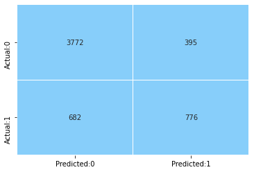

```python
cm = confusion_matrix(y_train,y_train_pred)
con_matrix = pd.DataFrame(cm,columns=['Predicted:0','Predicted:1'],index=['Actual:0','Actual:1'])
sns.heatmap(con_matrix,annot=True,fmt='d',cmap=ListedColormap(['Lightskyblue']),cbar=False,linewidths=0.1)
plt.show()
```

```python
y_test_pred = ada_model.predict(X_test)
print(classification_report(y_test,y_test_pred))
```

```
              precision    recall  f1-score   support

           0       0.83      0.91      0.87       996
           1       0.71      0.54      0.62       411

    accuracy                           0.80      1407
   macro avg       0.77      0.73      0.74      1407
weighted avg       0.80      0.80      0.79      1407
```

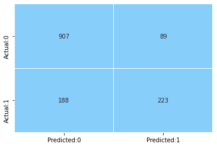

```python
cm = confusion_matrix(y_test,y_test_pred)
con_matrix = pd.DataFrame(cm,columns=['Predicted:0','Predicted:1'],index=['Actual:0','Actual:1'])
sns.heatmap(con_matrix,annot=True,fmt='d',cmap=ListedColormap(['Lightskyblue']),cbar=False,linewidths=0.1)
plt.show()
```

```python
Performance_report(ada_model, 'Ada Boosting')
report_card
```

|  | Model Name | AUC Score | Precision Score | Recall Score | Accuracy Score | Kappa Score | f1-score |
| --- | --- | --- | --- | --- | --- | --- | --- |
| 0 | Basic Decision Tree | 0.663973 | 0.541885 | 0.503650 | 0.730633 | 0.334886 | 0.522068 |
| 1 | Tuned Decision Tree | 0.708652 | 0.706485 | 0.503650 | 0.793888 | 0.455729 | 0.588068 |
| 2 | Basic RandomForest Tree | 0.692837 | 0.692857 | 0.472019 | 0.784648 | 0.425503 | 0.561505 |
| 3 | Basic KNN Tree | 0.655476 | 0.549858 | 0.469586 | 0.732765 | 0.324880 | 0.506562 |
| 4 | Tuned Random Forest Tree | 0.675630 | 0.767442 | 0.401460 | 0.789623 | 0.408464 | 0.527157 |
| 5 | Tuned KNN Tree | 0.718850 | 0.658046 | 0.557178 | 0.786070 | 0.458332 | 0.603426 |
| 6 | Basic Navie Bayes Tree | 0.769256 | 0.581181 | 0.766423 | 0.770434 | 0.492419 | 0.661070 |
| 7 | Ada Boosting | 0.726611 | 0.714744 | 0.542579 | 0.803127 | 0.487723 | 0.616874 |

### Hyper Parameter Tuning for Ada Boost

```python
params_list = {'n_estimators': [100, 120, 150, 200, 250, 300, 350],
   'learning_rate' : [0.1, 0.01, 0.001, 0.15, 0.015]}

ada_boost = AdaBoostClassifier()
```

```python
gscv_ada_boost = GridSearchCV(estimator=ada_boost, param_grid=params_list, cv=5)
```

```python
gscv_ada_boost_model = gscv_ada_boost.fit(X_train, y_train)
```

```python
gscv_ada_boost_model.best_params_
```

```
{'learning_rate': 0.1, 'n_estimators': 250}
```

```python
ada_tuned = AdaBoostClassifier(learning_rate=0.1, n_estimators=250)
ada_model_tuned = ada_tuned.fit(X_train, y_train)
```

```python
y_train_pred = ada_model_tuned.predict(X_train)
print(classification_report(y_train,y_train_pred))
```

```
              precision    recall  f1-score   support

           0       0.84      0.92      0.88      4167
           1       0.67      0.49      0.57      1458

    accuracy                           0.81      5625
   macro avg       0.76      0.70      0.72      5625
weighted avg       0.80      0.81      0.80      5625
```

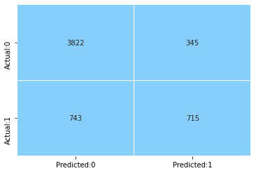

```python
cm = confusion_matrix(y_train,y_train_pred)
con_matrix = pd.DataFrame(cm,columns=['Predicted:0','Predicted:1'],index=['Actual:0','Actual:1'])
sns.heatmap(con_matrix,annot=True,fmt='d',cmap=ListedColormap(['Lightskyblue']),cbar=False,linewidths=0.1)
plt.show()
```

```python
y_test_pred = ada_model_tuned.predict(X_test)
print(classification_report(y_test,y_test_pred))
```

```
              precision    recall  f1-score   support

           0       0.82      0.93      0.87       996
           1       0.75      0.50      0.60       411

    accuracy                           0.81      1407
   macro avg       0.79      0.72      0.74      1407
weighted avg       0.80      0.81      0.79      1407
```

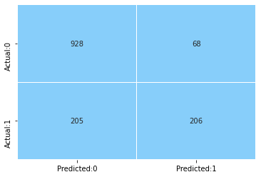

```python
cm = confusion_matrix(y_test,y_test_pred)
con_matrix = pd.DataFrame(cm,columns=['Predicted:0','Predicted:1'],index=['Actual:0','Actual:1'])
sns.heatmap(con_matrix,annot=True,fmt='d',cmap=ListedColormap(['Lightskyblue']),cbar=False,linewidths=0.1)
plt.show()
```

```python
Performance_report(ada_model_tuned, 'Tuned Ada Boost')
report_card
```

|  | Model Name | AUC Score | Precision Score | Recall Score | Accuracy Score | Kappa Score | f1-score |
| --- | --- | --- | --- | --- | --- | --- | --- |
| 0 | Basic Decision Tree | 0.663973 | 0.541885 | 0.503650 | 0.730633 | 0.334886 | 0.522068 |
| 1 | Tuned Decision Tree | 0.708652 | 0.706485 | 0.503650 | 0.793888 | 0.455729 | 0.588068 |
| 2 | Basic RandomForest Tree | 0.692837 | 0.692857 | 0.472019 | 0.784648 | 0.425503 | 0.561505 |
| 3 | Basic KNN Tree | 0.655476 | 0.549858 | 0.469586 | 0.732765 | 0.324880 | 0.506562 |
| 4 | Tuned Random Forest Tree | 0.675630 | 0.767442 | 0.401460 | 0.789623 | 0.408464 | 0.527157 |
| 5 | Tuned KNN Tree | 0.718850 | 0.658046 | 0.557178 | 0.786070 | 0.458332 | 0.603426 |
| 6 | Basic Navie Bayes Tree | 0.769256 | 0.581181 | 0.766423 | 0.770434 | 0.492419 | 0.661070 |
| 7 | Ada Boosting | 0.726611 | 0.714744 | 0.542579 | 0.803127 | 0.487723 | 0.616874 |
| 8 | Tuned Ada Boost | 0.716472 | 0.751825 | 0.501217 | 0.805970 | 0.479924 | 0.601460 |

### Gradient Boosting

```python
gboost_model = GradientBoostingClassifier(n_estimators = 150, max_depth = 10, random_state = 10)

# fit the model using fit() on train data
gboost_model.fit(X_train, y_train)
```

```
GradientBoostingClassifier(max_depth=10, n_estimators=150, random_state=10)
```

```python
y_train_pred = gboost_model.predict(X_train)
print(classification_report(y_train,y_train_pred))
```

```
              precision    recall  f1-score   support

           0       1.00      1.00      1.00      4167
           1       1.00      0.99      1.00      1458

    accuracy                           1.00      5625
   macro avg       1.00      1.00      1.00      5625
weighted avg       1.00      1.00      1.00      5625
```

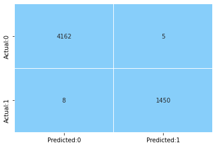

```python
cm = confusion_matrix(y_train,y_train_pred)
con_matrix = pd.DataFrame(cm,columns=['Predicted:0','Predicted:1'],index=['Actual:0','Actual:1'])
sns.heatmap(con_matrix,annot=True,fmt='d',cmap=ListedColormap(['Lightskyblue']),cbar=False,linewidths=0.1)
plt.show()
```

```python
y_test_pred = gboost_model.predict(X_test)
print(classification_report(y_test,y_test_pred))
```

```
              precision    recall  f1-score   support

           0       0.82      0.90      0.86       996
           1       0.68      0.51      0.58       411

    accuracy                           0.79      1407
   macro avg       0.75      0.70      0.72      1407
weighted avg       0.78      0.79      0.78      1407
```

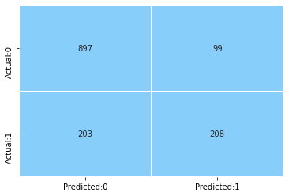

```python
cm = confusion_matrix(y_test,y_test_pred)
con_matrix = pd.DataFrame(cm,columns=['Predicted:0','Predicted:1'],index=['Actual:0','Actual:1'])
sns.heatmap(con_matrix,annot=True,fmt='d',cmap=ListedColormap(['Lightskyblue']),cbar=False,linewidths=0.1)
plt.show()
```

```python
Performance_report(gboost_model, 'Gadient Boosting')
report_card
```

|  | Model Name | AUC Score | Precision Score | Recall Score | Accuracy Score | Kappa Score | f1-score |
| --- | --- | --- | --- | --- | --- | --- | --- |
| 0 | Basic Decision Tree | 0.663973 | 0.541885 | 0.503650 | 0.730633 | 0.334886 | 0.522068 |
| 1 | Tuned Decision Tree | 0.708652 | 0.706485 | 0.503650 | 0.793888 | 0.455729 | 0.588068 |
| 2 | Basic RandomForest Tree | 0.692837 | 0.692857 | 0.472019 | 0.784648 | 0.425503 | 0.561505 |
| 3 | Basic KNN Tree | 0.655476 | 0.549858 | 0.469586 | 0.732765 | 0.324880 | 0.506562 |
| 4 | Tuned Random Forest Tree | 0.675630 | 0.767442 | 0.401460 | 0.789623 | 0.408464 | 0.527157 |
| 5 | Tuned KNN Tree | 0.718850 | 0.658046 | 0.557178 | 0.786070 | 0.458332 | 0.603426 |
| 6 | Basic Navie Bayes Tree | 0.769256 | 0.581181 | 0.766423 | 0.770434 | 0.492419 | 0.661070 |
| 7 | Ada Boosting | 0.726611 | 0.714744 | 0.542579 | 0.803127 | 0.487723 | 0.616874 |
| 8 | Tuned Ada Boost | 0.716472 | 0.751825 | 0.501217 | 0.805970 | 0.479924 | 0.601460 |
| 9 | Gadient Boosting | 0.703343 | 0.677524 | 0.506083 | 0.785359 | 0.439333 | 0.579387 |

### XGboost

|  | **import libraries** |
| --- | --- |

```python
import xgboost
```

```python
xgb = xgboost.XGBClassifier(max_depth = 10, gamma = 1)
```

```python
xgb_model = xgb.fit(X_train, y_train)
```

[output not shown]

```python
y_train_pred = xgb_model.predict(X_train)
print(classification_report(y_train,y_train_pred))
```

```
              precision    recall  f1-score   support

           0       0.96      0.97      0.97      4167
           1       0.92      0.88      0.90      1458

    accuracy                           0.95      5625
   macro avg       0.94      0.93      0.93      5625
weighted avg       0.95      0.95      0.95      5625
```

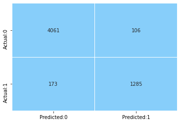

```python
cm = confusion_matrix(y_train,y_train_pred)
con_matrix = pd.DataFrame(cm,columns=['Predicted:0','Predicted:1'],index=['Actual:0','Actual:1'])
sns.heatmap(con_matrix,annot=True,fmt='d',cmap=ListedColormap(['Lightskyblue']),cbar=False,linewidths=0.1)
plt.show()
```

```python
y_test_pred = xgb_model.predict(X_test)
print(classification_report(y_test,y_test_pred))
```

```
              precision    recall  f1-score   support

           0       0.83      0.90      0.86       996
           1       0.69      0.54      0.61       411

    accuracy                           0.79      1407
   macro avg       0.76      0.72      0.73      1407
weighted avg       0.79      0.79      0.79      1407
```

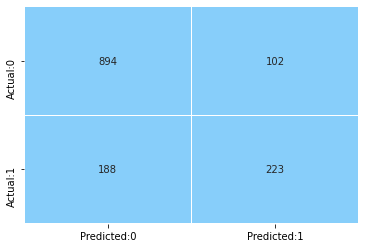

```python
cm = confusion_matrix(y_test,y_test_pred)
con_matrix = pd.DataFrame(cm,columns=['Predicted:0','Predicted:1'],index=['Actual:0','Actual:1'])
sns.heatmap(con_matrix,annot=True,fmt='d',cmap=ListedColormap(['Lightskyblue']),cbar=False,linewidths=0.1)
plt.show()
```

```python
Performance_report(xgb_model, 'XGBoost model')
report_card
```

|  | Model Name | AUC Score | Precision Score | Recall Score | Accuracy Score | Kappa Score | f1-score |
| --- | --- | --- | --- | --- | --- | --- | --- |
| 0 | Basic Decision Tree | 0.663973 | 0.541885 | 0.503650 | 0.730633 | 0.334886 | 0.522068 |
| 1 | Tuned Decision Tree | 0.708652 | 0.706485 | 0.503650 | 0.793888 | 0.455729 | 0.588068 |
| 2 | Basic RandomForest Tree | 0.692837 | 0.692857 | 0.472019 | 0.784648 | 0.425503 | 0.561505 |
| 3 | Basic KNN Tree | 0.655476 | 0.549858 | 0.469586 | 0.732765 | 0.324880 | 0.506562 |
| 4 | Tuned Random Forest Tree | 0.675630 | 0.767442 | 0.401460 | 0.789623 | 0.408464 | 0.527157 |
| 5 | Tuned KNN Tree | 0.718850 | 0.658046 | 0.557178 | 0.786070 | 0.458332 | 0.603426 |
| 6 | Basic Navie Bayes Tree | 0.769256 | 0.581181 | 0.766423 | 0.770434 | 0.492419 | 0.661070 |
| 7 | Ada Boosting | 0.726611 | 0.714744 | 0.542579 | 0.803127 | 0.487723 | 0.616874 |
| 8 | Tuned Ada Boost | 0.716472 | 0.751825 | 0.501217 | 0.805970 | 0.479924 | 0.601460 |
| 9 | Gadient Boosting | 0.703343 | 0.677524 | 0.506083 | 0.785359 | 0.439333 | 0.579387 |
| 10 | XGBoost model | 0.720085 | 0.686154 | 0.542579 | 0.793888 | 0.468989 | 0.605978 |

#### Hyper Parameter Tuning for XGboost

```python
tuning_parameters = {'learning_rate': [0.1, 0.2, 0.3, 0.4, 0.5, 0.6],
                     'max_depth': range(3,10),
                     'gamma': [0, 1, 2, 3, 4]}

# instantiate the 'XGBClassifier'
xgb_mod = xgboost.XGBClassifier()

xgb_grid = GridSearchCV(estimator = xgb_mod, param_grid = tuning_parameters, cv = 3, scoring = 'roc_auc')

# fit the model on X_train and y_train using fit()
xgb_grid.fit(X_train, y_train)

# get the best parameters
print('Best parameters for XGBoost classifier: ', xgb_grid.best_params_, '\n')
```

[output not shown]

[output cut: 615 more lines]

```python
xgb_tuned = xgboost.XGBClassifier(gamma = 2, learning_rate = 0.1, max_depth = 4)
xgb_model_tuned = xgb_tuned.fit(X_train, y_train)
```

[output not shown]

```python
y_train_pred = xgb_model_tuned.predict(X_train)
print(classification_report(y_train,y_train_pred))
```

```
              precision    recall  f1-score   support

           0       0.86      0.92      0.89      4167
           1       0.70      0.56      0.62      1458

    accuracy                           0.82      5625
   macro avg       0.78      0.74      0.75      5625
weighted avg       0.82      0.82      0.82      5625
```

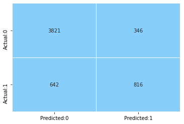

```python
cm = confusion_matrix(y_train,y_train_pred)
con_matrix = pd.DataFrame(cm,columns=['Predicted:0','Predicted:1'],index=['Actual:0','Actual:1'])
sns.heatmap(con_matrix,annot=True,fmt='d',cmap=ListedColormap(['Lightskyblue']),cbar=False,linewidths=0.1)
plt.show()
```

```python
y_test_pred = xgb_model_tuned.predict(X_test)
print(classification_report(y_test,y_test_pred))
```

```
              precision    recall  f1-score   support

           0       0.82      0.92      0.87       996
           1       0.73      0.52      0.61       411

    accuracy                           0.80      1407
   macro avg       0.78      0.72      0.74      1407
weighted avg       0.80      0.80      0.79      1407
```

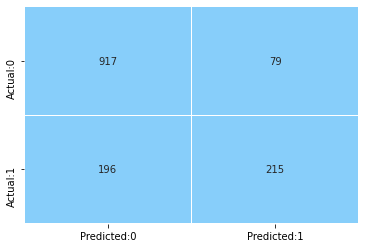

```python
cm = confusion_matrix(y_test,y_test_pred)
con_matrix = pd.DataFrame(cm,columns=['Predicted:0','Predicted:1'],index=['Actual:0','Actual:1'])
sns.heatmap(con_matrix,annot=True,fmt='d',cmap=ListedColormap(['Lightskyblue']),cbar=False,linewidths=0.1)
plt.show()
```

```python
Performance_report(xgb_model_tuned, 'Tunned XGBoost')
report_card
```

|  | Model Name | AUC Score | Precision Score | Recall Score | Accuracy Score | Kappa Score | f1-score |
| --- | --- | --- | --- | --- | --- | --- | --- |
| 0 | Basic Decision Tree | 0.663973 | 0.541885 | 0.503650 | 0.730633 | 0.334886 | 0.522068 |
| 1 | Tuned Decision Tree | 0.708652 | 0.706485 | 0.503650 | 0.793888 | 0.455729 | 0.588068 |
| 2 | Basic RandomForest Tree | 0.692837 | 0.692857 | 0.472019 | 0.784648 | 0.425503 | 0.561505 |
| 3 | Basic KNN Tree | 0.655476 | 0.549858 | 0.469586 | 0.732765 | 0.324880 | 0.506562 |
| 4 | Tuned Random Forest Tree | 0.675630 | 0.767442 | 0.401460 | 0.789623 | 0.408464 | 0.527157 |
| 5 | Tuned KNN Tree | 0.718850 | 0.658046 | 0.557178 | 0.786070 | 0.458332 | 0.603426 |
| 6 | Basic Navie Bayes Tree | 0.769256 | 0.581181 | 0.766423 | 0.770434 | 0.492419 | 0.661070 |
| 7 | Ada Boosting | 0.726611 | 0.714744 | 0.542579 | 0.803127 | 0.487723 | 0.616874 |
| 8 | Tuned Ada Boost | 0.716472 | 0.751825 | 0.501217 | 0.805970 | 0.479924 | 0.601460 |
| 9 | Gadient Boosting | 0.703343 | 0.677524 | 0.506083 | 0.785359 | 0.439333 | 0.579387 |
| 10 | XGBoost model | 0.720085 | 0.686154 | 0.542579 | 0.793888 | 0.468989 | 0.605978 |
| 11 | Tunned XGBoost | 0.721899 | 0.731293 | 0.523114 | 0.804549 | 0.484284 | 0.609929 |

# Final Model Building

## Train Test Split

```python
X_train, X_test, y_train, y_test = train_test_split(df, y, test_size=0.2, random_state=123)
```

## Standardization

```python
# Standardizing the data with Standard Scaler
ss = StandardScaler()

X_train = ss.fit_transform(X_train)
X_test = ss.transform(X_test)
```

```python
#display standardised data in a data frame

X_train = pd.DataFrame(X_train, columns = df.columns)
X_train.shape
```

```
(5625, 23)
```

```python
y_train = y_train.reset_index(drop=True)
y_train.head()
```

|  | Churn_Yes |
| --- | --- |
| 0 | 1 |
| 1 | 0 |
| 2 | 0 |
| 3 | 1 |
| 4 | 0 |

```python
#display standardised data in a data frame

X_test = pd.DataFrame(X_test, columns = df.columns)
X_test.head()
```

|  | tenure | MonthlyCharges | TotalCharges | gender_Male | SeniorCitizen_1 | Partner_Yes | Dependents_Yes | PhoneService_Yes | MultipleLines_Yes | InternetService_Fiber optic | InternetService_No | OnlineSecurity_Yes | OnlineBackup_Yes | DeviceProtection_Yes | TechSupport_Yes | StreamingTV_Yes | StreamingMovies_Yes | Contract_One year | Contract_Two year | PaperlessBilling_Yes | PaymentMethod_Credit card (automatic) | PaymentMethod_Electronic check | PaymentMethod_Mailed check |
| --- | --- | --- | --- | --- | --- | --- | --- | --- | --- | --- | --- | --- | --- | --- | --- | --- | --- | --- | --- | --- | --- | --- | --- |
| 0 | 0.098812 | -1.497286 | -0.714306 | 0.992737 | -0.436147 | -0.964539 | -0.656455 | 0.330859 | -0.862035 | -0.887045 | 1.938784 | -0.639308 | -0.727860 | -0.741917 | -0.649255 | -0.792809 | -0.804453 | -0.513853 | 1.773464 | 0.831397 | -0.529572 | -0.709371 | 1.831315 |
| 1 | -0.594228 | 0.359689 | -0.411190 | 0.992737 | -0.436147 | -0.964539 | -0.656455 | 0.330859 | -0.862035 | 1.127339 | -0.515787 | -0.639308 | -0.727860 | -0.741917 | 1.540228 | -0.792809 | -0.804453 | -0.513853 | -0.563868 | 0.831397 | -0.529572 | -0.709371 | -0.546056 |
| 2 | 1.321824 | 1.268172 | 1.974209 | 0.992737 | 2.292804 | 1.036764 | -0.656455 | 0.330859 | 1.160045 | 1.127339 | -0.515787 | -0.639308 | 1.373891 | 1.347859 | -0.649255 | 1.261337 | 1.243080 | 1.946082 | -0.563868 | 0.831397 | -0.529572 | -0.709371 | -0.546056 |
| 3 | 0.669551 | -0.293753 | 0.208356 | -1.007316 | -0.436147 | 1.036764 | -0.656455 | -3.022439 | -0.862035 | -0.887045 | -0.515787 | -0.639308 | 1.373891 | -0.741917 | 1.540228 | 1.261337 | 1.243080 | 1.946082 | -0.563868 | 0.831397 | 1.888318 | -0.709371 | -0.546056 |
| 4 | 0.180346 | 1.146486 | 0.640328 | -1.007316 | -0.436147 | 1.036764 | -0.656455 | 0.330859 | 1.160045 | 1.127339 | -0.515787 | -0.639308 | -0.727860 | 1.347859 | -0.649255 | 1.261337 | 1.243080 | -0.513853 | -0.563868 | 0.831397 | -0.529572 | 1.409700 | -0.546056 |

```python
y_test = y_test.reset_index(drop=True)
y_test.head()
```

|  | Churn_Yes |
| --- | --- |
| 0 | 0 |
| 1 | 0 |
| 2 | 0 |
| 3 | 0 |
| 4 | 1 |

```python
print(X_train.shape)
print(X_test.shape)
print(y_train.shape)
print(y_test.shape)
```

```
(5625, 23)
(1407, 23)
(5625, 1)
(1407, 1)
```

# UPsampling SMOTE

```
Before Up-sampling (train) : Churn_Yes
0            4167
1            1458
dtype: int64
```

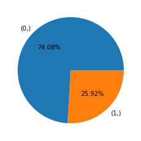

```python
# Before Sampling the data
print(f'Before Up-sampling (train) : {y_train.value_counts()}')

plt.pie(y_train.value_counts(), labels = y_train.value_counts().index, autopct= '%.2f%%')
plt.show()
```

|  | **import libraries** |
| --- | --- |

```python
from imblearn.over_sampling import SMOTE
```

```python
# For Train
sm = SMOTE(sampling_strategy = 1 ,k_neighbors = 5, random_state=1)   #Synthetic Minority Over Sampling Technique
X_train_res, y_train_res = sm.fit_resample(X_train, y_train)
```

```
After Up-sampling (train) : Churn_Yes
1            4167
0            4167
dtype: int64
```

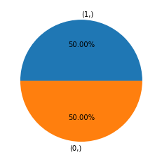

```python
# After Sampling the data
print(f'After Up-sampling (train) : {y_train_res.value_counts()}')

plt.pie(y_train_res.value_counts(), labels = y_train_res.value_counts().index, autopct= '%.2f%%')
plt.show()
```

### Test Model

```python
import statsmodels.api as sm

Xc_train_res = sm.add_constant(X_train_res)
Xc_test = sm.add_constant(X_test)

# create a logistic model
log_model = sm.Logit(y_train_res, Xc_train_res).fit()

# display the summary
print(log_model.summary())
```

```
Optimization terminated successfully.
         Current function value: inf
         Iterations 7
                           Logit Regression Results
==============================================================================
Dep. Variable:              Churn_Yes   No. Observations:                 8334
Model:                          Logit   Df Residuals:                     8310
Method:                           MLE   Df Model:                           23
Date:                Wed, 30 Jun 2021   Pseudo R-squ.:                     inf
Time:                        11:37:14   Log-Likelihood:                   -inf
converged:                       True   LL-Null:                        0.0000
Covariance Type:            nonrobust   LLR p-value:                     1.000
=========================================================================================================
                                            coef    std err          z      P>|z|      [0.025      0.975]
---------------------------------------------------------------------------------------------------------
const                                    -0.8077      0.043    -18.931      0.000      -0.891      -0.724
tenure                                   -1.5621      0.122    -12.794      0.000      -1.801      -1.323
MonthlyCharges                           -1.8196      0.868     -2.096      0.036      -3.521      -0.118
TotalCharges                              0.8978      0.129      6.942      0.000       0.644       1.151
gender_Male                              -0.0047      0.028     -0.166      0.868      -0.060       0.051
SeniorCitizen_1                           0.0370      0.028      1.311      0.190      -0.018       0.092
Partner_Yes                              -0.0356      0.035     -1.023      0.306      -0.104       0.033
Dependents_Yes                           -0.1002      0.036     -2.797      0.005      -0.170      -0.030
PhoneService_Yes                          0.1920      0.176      1.092      0.275      -0.152       0.536
MultipleLines_Yes                         0.2741      0.080      3.426      0.001       0.117       0.431
InternetService_Fiber optic               1.0642      0.360      2.956      0.003       0.358       1.770
InternetService_No                       -0.9956      0.300     -3.324      0.001      -1.583      -0.409
OnlineSecurity_Yes                       -0.0644      0.073     -0.883      0.377      -0.207       0.078
OnlineBackup_Yes                          0.0243      0.076      0.322      0.748      -0.124       0.172
DeviceProtection_Yes                      0.1373      0.076      1.800      0.072      -0.012       0.287
TechSupport_Yes                          -0.0231      0.074     -0.312      0.755      -0.168       0.122
StreamingTV_Yes                           0.3911      0.145      2.703      0.007       0.108       0.675
StreamingMovies_Yes                       0.3890      0.145      2.679      0.007       0.104       0.674
Contract_One year                        -0.3057      0.037     -8.357      0.000      -0.377      -0.234
Contract_Two year                        -0.6350      0.059    -10.689      0.000      -0.751      -0.519
PaperlessBilling_Yes                      0.1621      0.032      5.083      0.000       0.100       0.225
PaymentMethod_Credit card (automatic)    -0.0737      0.040     -1.846      0.065      -0.152       0.005
PaymentMethod_Electronic check            0.1514      0.039      3.915      0.000       0.076       0.227
PaymentMethod_Mailed check               -0.0096      0.041     -0.235      0.814      -0.089       0.070
=========================================================================================================
```

```python
log_reg_best = log_model.pvalues[log_model.pvalues < 0.05].index
len(log_reg_best)
```

```
14
```

#### For Train

|  | **import libraries** |
| --- | --- |

```python
from sklearn.metrics import classification_report, confusion_matrix
```

```python
# calculate the probability for train data set using model created
y_train_pred_prob = log_model.predict(Xc_train_res)

# predict the test values
y_train_pred = [0 if x < 0.5 else 1 for x in y_train_pred_prob]

# display the classification report
print(classification_report(y_train_res,y_train_pred))
```

```
              precision    recall  f1-score   support

           0       0.80      0.73      0.76      4167
           1       0.75      0.81      0.78      4167

    accuracy                           0.77      8334
   macro avg       0.77      0.77      0.77      8334
weighted avg       0.77      0.77      0.77      8334
```

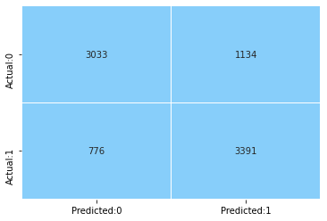

```python
cm = confusion_matrix(y_train_res,y_train_pred)
con_matrix = pd.DataFrame(cm,columns=['Predicted:0','Predicted:1'],index=['Actual:0','Actual:1'])
sns.heatmap(con_matrix,annot=True,fmt='d',cmap=ListedColormap(['Lightskyblue']),cbar=False,linewidths=0.1)
plt.show()
```

#### For Test

```python
# calculate the probability for test data set using model created
y_test_pred_prob = log_model.predict(Xc_test)

# predict the test values
y_test_pred = [0 if x < 0.5 else 1 for x in y_test_pred_prob]

# display the classification report
print(classification_report(y_test,y_test_pred))
```

```
              precision    recall  f1-score   support

           0       0.90      0.75      0.82       996
           1       0.56      0.79      0.66       411

    accuracy                           0.76      1407
   macro avg       0.73      0.77      0.74      1407
weighted avg       0.80      0.76      0.77      1407
```

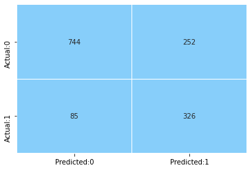

```python
cm = confusion_matrix(y_test,y_test_pred)
con_matrix = pd.DataFrame(cm,columns=['Predicted:0','Predicted:1'],index=['Actual:0','Actual:1'])
sns.heatmap(con_matrix,annot=True,fmt='d',cmap=ListedColormap(['Lightskyblue']),cbar=False,linewidths=0.1)
plt.show()
```

# Best Featuers Selection

```python
# Importing the required library
from sklearn.feature_selection import SelectKBest, f_classif, chi2

kbest = SelectKBest(score_func=f_classif, k=13)

best_features = kbest.fit_transform(X_train_res, y_train_res)

mask = kbest.get_support()

new_features = X_train_res.columns[mask]
```

```python
new_features
```

```
Index(['tenure', 'MonthlyCharges', 'TotalCharges', 'Partner_Yes',
       'Dependents_Yes', 'InternetService_Fiber optic', 'InternetService_No',
       'OnlineSecurity_Yes', 'TechSupport_Yes', 'Contract_One year',
       'Contract_Two year', 'PaperlessBilling_Yes',
       'PaymentMethod_Electronic check'],
      dtype='object')
```

```python
x_best_train = X_train_res[new_features]
x_best_test = X_test[new_features]
```

```python
x_best_train.shape, x_best_test.shape
```

```
((8334, 13), (1407, 13))
```

#### Required Datasets

```python
# Train
print(f'For Train \n')
print(x_best_train.shape)
print(y_train_res.shape)
# Test
print(f'For Test \n')
print(x_best_test.shape)
print(y_test.shape)
```

```
For Train

(8334, 13)
(8334, 1)
For Test

(1407, 13)
(1407, 1)
```

# Final Model Building

## Logistic Regression

```python
Xc_train = sm.add_constant(x_best_train)
Xc_test = sm.add_constant(x_best_test)
```

```python
# create a logistic model
log_model = sm.Logit(y_train_res, Xc_train).fit()

# display the summary
print(log_model.summary())
```

```
Optimization terminated successfully.
         Current function value: inf
         Iterations 7
                           Logit Regression Results
==============================================================================
Dep. Variable:              Churn_Yes   No. Observations:                 8334
Model:                          Logit   Df Residuals:                     8320
Method:                           MLE   Df Model:                           13
Date:                Wed, 30 Jun 2021   Pseudo R-squ.:                     inf
Time:                        11:37:58   Log-Likelihood:                   -inf
converged:                       True   LL-Null:                        0.0000
Covariance Type:            nonrobust   LLR p-value:                     1.000
==================================================================================================
                                     coef    std err          z      P>|z|      [0.025      0.975]
--------------------------------------------------------------------------------------------------
const                             -0.7936      0.042    -18.693      0.000      -0.877      -0.710
tenure                            -1.5400      0.120    -12.883      0.000      -1.774      -1.306
MonthlyCharges                     0.0570      0.096      0.592      0.554      -0.132       0.246
TotalCharges                       0.9322      0.127      7.338      0.000       0.683       1.181
Partner_Yes                       -0.0151      0.034     -0.443      0.658      -0.082       0.052
Dependents_Yes                    -0.1268      0.035     -3.647      0.000      -0.195      -0.059
InternetService_Fiber optic        0.2478      0.063      3.948      0.000       0.125       0.371
InternetService_No                -0.4319      0.053     -8.084      0.000      -0.537      -0.327
OnlineSecurity_Yes                -0.2267      0.033     -6.839      0.000      -0.292      -0.162
TechSupport_Yes                   -0.1706      0.035     -4.929      0.000      -0.239      -0.103
Contract_One year                 -0.3043      0.036     -8.459      0.000      -0.375      -0.234
Contract_Two year                 -0.6298      0.059    -10.701      0.000      -0.745      -0.514
PaperlessBilling_Yes               0.1845      0.032      5.852      0.000       0.123       0.246
PaymentMethod_Electronic check     0.2103      0.028      7.414      0.000       0.155       0.266
==================================================================================================
```

```python
# calculate the probability for train data set using model created
y_train_pred_prob = log_model.predict(Xc_train)

# predict the test values
y_train_pred = [0 if x < 0.5 else 1 for x in y_train_pred_prob]

# display the classification report
print(classification_report(y_train_res,y_train_pred))
```

```
              precision    recall  f1-score   support

           0       0.79      0.73      0.76      4167
           1       0.75      0.81      0.78      4167

    accuracy                           0.77      8334
   macro avg       0.77      0.77      0.77      8334
weighted avg       0.77      0.77      0.77      8334
```

```python
# calculate the probability for train data set using model created
y_train_pred_prob = log_model.predict(Xc_train)

# predict the test values
y_train_pred = [0 if x < 0.4 else 1 for x in y_train_pred_prob]

# display the classification report
print(classification_report(y_train_res,y_train_pred))
```

```
              precision    recall  f1-score   support

           0       0.84      0.64      0.72      4167
           1       0.71      0.88      0.78      4167

    accuracy                           0.76      8334
   macro avg       0.77      0.76      0.75      8334
weighted avg       0.77      0.76      0.75      8334
```

```python
from sklearn import metrics
```

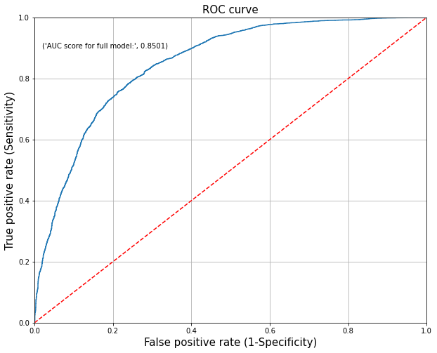

```python
plt.figure(figsize=(10,8))
fpr, tpr, thresholds = roc_curve(y_train_res,y_train_pred_prob)
plt.plot(fpr,tpr)

plt.xlim([0.0,1.0])
plt.ylim([0.0,1.0])

plt.plot([0,1],[0,1],'r--')

plt.title('ROC curve', fontsize = 15)
plt.xlabel('False positive rate (1-Specificity)', fontsize = 15)
plt.ylabel('True positive rate (Sensitivity)', fontsize = 15)

plt.text(x=0.02,y=0.9,s=('AUC score for full model:',round(metrics.roc_auc_score(y_train_res,y_train_pred_prob),4)))


plt.grid(True)
```

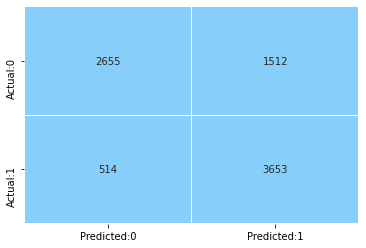

```python
# create Confusion matrix for train data
cm = confusion_matrix(y_train_res,y_train_pred)

#plot the confussion matrix for train data
con_matrix = pd.DataFrame(cm,columns=['Predicted:0','Predicted:1'],index=['Actual:0','Actual:1'])
sns.heatmap(con_matrix,annot=True,fmt='d',cmap=ListedColormap(['Lightskyblue']),cbar=False,linewidths=0.1)
plt.show()
```

```python
# calculate the probability for test data set using model created
y_test_pred_prob = log_model.predict(Xc_test)

# predict the test values
y_test_pred = [0 if x < 0.5 else 1 for x in y_test_pred_prob]

# display the classification report
print(classification_report(y_test,y_test_pred))
```

```
              precision    recall  f1-score   support

           0       0.90      0.75      0.82       996
           1       0.57      0.80      0.66       411

    accuracy                           0.76      1407
   macro avg       0.73      0.77      0.74      1407
weighted avg       0.80      0.76      0.77      1407
```

```python
# calculate the probability for test data set using model created
y_test_pred_prob = log_model.predict(Xc_test)

# predict the test values
y_test_pred = [0 if x < 0.4 else 1 for x in y_test_pred_prob]

# display the classification report
print(classification_report(y_test,y_test_pred))
```

```
              precision    recall  f1-score   support

           0       0.93      0.66      0.77       996
           1       0.52      0.89      0.65       411

    accuracy                           0.73      1407
   macro avg       0.73      0.77      0.71      1407
weighted avg       0.81      0.73      0.74      1407
```

```python
# calculate the probability for test data set using model created
y_test_pred_prob = log_model.predict(Xc_test)

# predict the test values
y_test_pred = [0 if x < 0.45 else 1 for x in y_test_pred_prob]

# display the classification report
print(classification_report(y_test,y_test_pred))
```

```
              precision    recall  f1-score   support

           0       0.92      0.71      0.80       996
           1       0.54      0.84      0.66       411

    accuracy                           0.75      1407
   macro avg       0.73      0.78      0.73      1407
weighted avg       0.81      0.75      0.76      1407
```

```python
# calculate the probability for test data set using model created
y_test_pred_prob = log_model.predict(Xc_test)

# predict the test values
y_test_pred = [0 if x < 0.48 else 1 for x in y_test_pred_prob]

# display the classification report
print(classification_report(y_test,y_test_pred))
```

```
              precision    recall  f1-score   support

           0       0.91      0.73      0.81       996
           1       0.56      0.82      0.67       411

    accuracy                           0.76      1407
   macro avg       0.73      0.78      0.74      1407
weighted avg       0.81      0.76      0.77      1407
```

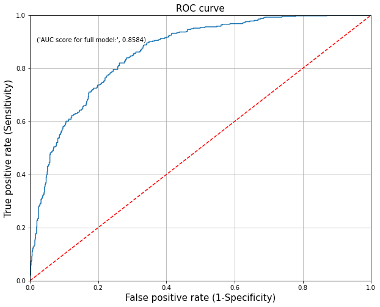

```python
plt.figure(figsize=(10,8))
fpr, tpr, thresholds = roc_curve(y_test,y_test_pred_prob)
plt.plot(fpr,tpr)

plt.xlim([0.0,1.0])
plt.ylim([0.0,1.0])

plt.plot([0,1],[0,1],'r--')

plt.title('ROC curve', fontsize = 15)
plt.xlabel('False positive rate (1-Specificity)', fontsize = 15)
plt.ylabel('True positive rate (Sensitivity)', fontsize = 15)

plt.text(x=0.02,y=0.9,s=('AUC score for full model:',round(metrics.roc_auc_score(y_test,y_test_pred_prob),4)))


plt.grid(True)
```

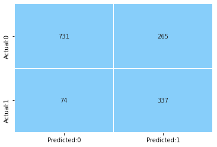

```python
# create Confusion matrix for test data
cm = confusion_matrix(y_test,y_test_pred)

#plot the confussion matrix for test data
con_matrix = pd.DataFrame(cm,columns=['Predicted:0','Predicted:1'],index=['Actual:0','Actual:1'])
sns.heatmap(con_matrix,annot=True,fmt='d',cmap=ListedColormap(['Lightskyblue']),cbar=False,linewidths=0.1)
plt.show()
```

## Calculating the Youden's Index

```python
# Getting the fpr, tpr, thres score
fpr, tpr, thresholds = roc_curve(y_test,y_test_pred_prob)

# create a dataframe to store the values for false positive rate, true positive rate and threshold
youdens_table = pd.DataFrame({'TPR': tpr,
                             'FPR': fpr,
                             'Threshold': thresholds})

# calculate the difference between TPR and FPR for each threshold and store the values in a new column 'Difference'
youdens_table['Difference'] = youdens_table.TPR - youdens_table.FPR

# sort the dataframe based on the values of difference
# 'ascending = False'

youdens_table = youdens_table.sort_values('Difference', ascending = False).reset_index(drop = True)

# print the first five observations
youdens_table.head()
```

|  | TPR | FPR | Threshold | Difference |
| --- | --- | --- | --- | --- |
| 0 | 0.819951 | 0.262048 | 0.487113 | 0.557903 |
| 1 | 0.839416 | 0.283133 | 0.457080 | 0.556284 |
| 2 | 0.834550 | 0.281124 | 0.458797 | 0.553425 |
| 3 | 0.885645 | 0.332329 | 0.401539 | 0.553315 |
| 4 | 0.895377 | 0.342369 | 0.393660 | 0.553008 |

# Decision Tree

|  | **import libraries** |
| --- | --- |

```python
# import decision tree classifier from sklear tream module
from sklearn.tree import DecisionTreeClassifier
from sklearn import tree
from sklearn.model_selection import GridSearchCV
```

```python
# Intantiate DecisionTreeClassifier
# using entropy as criteria
# chosing random state as 10
dt = DecisionTreeClassifier(criterion = 'entropy', random_state = 10)

# fit model on train data set
dt_model = dt.fit(x_best_train,y_train_res)
```

##### For Train

```python
# predict target values using model built
y_train_prob = dt_model.predict(x_best_train)

y_train_pred = [0 if x< 0.5 else 1 for x in y_train_prob]

# display the classification report
print(classification_report(y_train_res,y_train_pred))
```

```
              precision    recall  f1-score   support

           0       1.00      1.00      1.00      4167
           1       1.00      1.00      1.00      4167

    accuracy                           1.00      8334
   macro avg       1.00      1.00      1.00      8334
weighted avg       1.00      1.00      1.00      8334
```

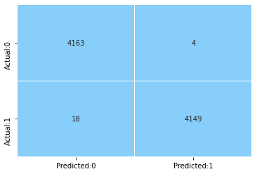

```python
cm = confusion_matrix(y_train_res,y_train_pred)
con_matrix = pd.DataFrame(cm,columns=['Predicted:0','Predicted:1'],index=['Actual:0','Actual:1'])
sns.heatmap(con_matrix,annot=True,fmt='d',cmap=ListedColormap(['Lightskyblue']),cbar=False,linewidths=0.1)
plt.show()
```

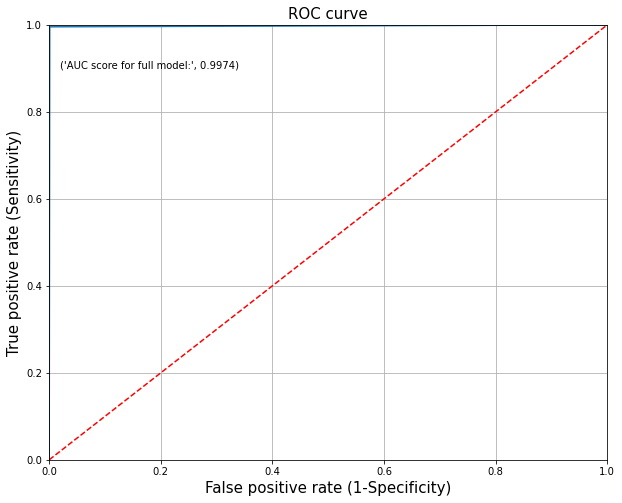

```python
plt.figure(figsize=(10,8))
fpr, tpr, thresholds = roc_curve(y_train_res,y_train_prob)
plt.plot(fpr,tpr)

plt.xlim([0.0,1.0])
plt.ylim([0.0,1.0])

plt.plot([0,1],[0,1],'r--')

plt.title('ROC curve', fontsize = 15)
plt.xlabel('False positive rate (1-Specificity)', fontsize = 15)
plt.ylabel('True positive rate (Sensitivity)', fontsize = 15)

plt.text(x=0.02,y=0.9,s=('AUC score for full model:',round(metrics.roc_auc_score(y_train_res,y_train_prob),4)))


plt.grid(True)
```

##### For Test

```python
# predict target values using model built
y_test_prob = dt_model.predict(x_best_test)

y_test_pred = [0 if x<0.5 else 1 for x in y_test_prob]

# display the classification report
print(classification_report(y_test,y_test_pred))
```

```
              precision    recall  f1-score   support

           0       0.82      0.79      0.81       996
           1       0.54      0.59      0.56       411

    accuracy                           0.73      1407
   macro avg       0.68      0.69      0.69      1407
weighted avg       0.74      0.73      0.74      1407
```

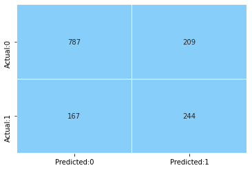

```python
cm = confusion_matrix(y_test,y_test_pred)
con_matrix = pd.DataFrame(cm,columns=['Predicted:0','Predicted:1'],index=['Actual:0','Actual:1'])
sns.heatmap(con_matrix,annot=True,fmt='d',cmap=ListedColormap(['Lightskyblue']),cbar=False,linewidths=0.1)
plt.show()
```

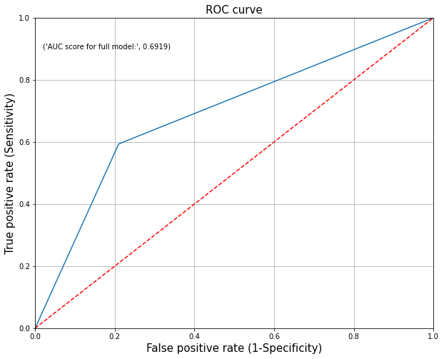

```python
plt.figure(figsize=(10,8))
fpr, tpr, thresholds = roc_curve(y_test,y_test_prob)
plt.plot(fpr,tpr)

plt.xlim([0.0,1.0])
plt.ylim([0.0,1.0])

plt.plot([0,1],[0,1],'r--')

plt.title('ROC curve', fontsize = 15)
plt.xlabel('False positive rate (1-Specificity)', fontsize = 15)
plt.ylabel('True positive rate (Sensitivity)', fontsize = 15)

plt.text(x=0.02,y=0.9,s=('AUC score for full model:',round(metrics.roc_auc_score(y_test,y_test_prob),4)))


plt.grid(True)
```

```python
X_test = x_best_test
```

```python
Performance_report(dt_model, 'Decision Tree with Best Features')
report_card
```

|  | Model Name | AUC Score | Precision Score | Recall Score | Accuracy Score | Kappa Score | f1-score |
| --- | --- | --- | --- | --- | --- | --- | --- |
| 0 | Basic Decision Tree | 0.663973 | 0.541885 | 0.503650 | 0.730633 | 0.334886 | 0.522068 |
| 1 | Tuned Decision Tree | 0.708652 | 0.706485 | 0.503650 | 0.793888 | 0.455729 | 0.588068 |
| 2 | Basic RandomForest Tree | 0.692837 | 0.692857 | 0.472019 | 0.784648 | 0.425503 | 0.561505 |
| 3 | Basic KNN Tree | 0.655476 | 0.549858 | 0.469586 | 0.732765 | 0.324880 | 0.506562 |
| 4 | Tuned Random Forest Tree | 0.675630 | 0.767442 | 0.401460 | 0.789623 | 0.408464 | 0.527157 |
| 5 | Tuned KNN Tree | 0.718850 | 0.658046 | 0.557178 | 0.786070 | 0.458332 | 0.603426 |
| 6 | Basic Navie Bayes Tree | 0.769256 | 0.581181 | 0.766423 | 0.770434 | 0.492419 | 0.661070 |
| 7 | Ada Boosting | 0.726611 | 0.714744 | 0.542579 | 0.803127 | 0.487723 | 0.616874 |
| 8 | Tuned Ada Boost | 0.716472 | 0.751825 | 0.501217 | 0.805970 | 0.479924 | 0.601460 |
| 9 | Gadient Boosting | 0.703343 | 0.677524 | 0.506083 | 0.785359 | 0.439333 | 0.579387 |
| 10 | XGBoost model | 0.720085 | 0.686154 | 0.542579 | 0.793888 | 0.468989 | 0.605978 |
| 11 | Tunned XGBoost | 0.721899 | 0.731293 | 0.523114 | 0.804549 | 0.484284 | 0.609929 |
| 12 | Decision Tree with Best Features | 0.691917 | 0.538631 | 0.593674 | 0.732765 | 0.372651 | 0.564815 |

## HyperParameter Tuning for Decision Tree

|  | **import libraries** |
| --- | --- |

```python
from sklearn.model_selection import GridSearchCV
```

```python
tuned_paramaters = [{'criterion': ['entropy', 'gini'],
                     'max_depth': range(2, 10),
                     'max_features': ["sqrt", "log2"],
                     'min_samples_split': range(2,10),
                     'min_samples_leaf': range(1,10),
                     'max_leaf_nodes': range(1, 10)}]
```

```python
DT = DecisionTreeClassifier()
gscv_dt = GridSearchCV(estimator=DT, param_grid=tuned_paramaters, cv=5)
gscv_dt_model = gscv_dt.fit(x_best_train,y_train_res)
gscv_dt_model.best_params_
```

```
{'criterion': 'entropy',
 'max_depth': 7,
 'max_features': 'sqrt',
 'max_leaf_nodes': 9,
 'min_samples_leaf': 8,
 'min_samples_split': 5}
```

```python
dt_tuned = DecisionTreeClassifier(criterion='gini', max_depth=9, max_features='log2', max_leaf_nodes=7, min_samples_leaf=6, min_samples_split=6)
dt_tuned_model = dt_tuned.fit(x_best_train,y_train_res)
```

##### For Train

```python
# predict target values using model built
y_train_prob = dt_tuned_model.predict(x_best_train)

y_train_pred = [0 if x< 0.5 else 1 for x in y_train_prob]

# display the classification report
print(classification_report(y_train_res,y_train_pred))
```

```
              precision    recall  f1-score   support

           0       0.80      0.61      0.69      4167
           1       0.68      0.85      0.76      4167

    accuracy                           0.73      8334
   macro avg       0.74      0.73      0.72      8334
weighted avg       0.74      0.73      0.72      8334
```

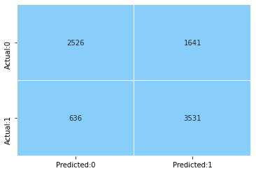

```python
cm = confusion_matrix(y_train_res,y_train_pred)
con_matrix = pd.DataFrame(cm,columns=['Predicted:0','Predicted:1'],index=['Actual:0','Actual:1'])
sns.heatmap(con_matrix,annot=True,fmt='d',cmap=ListedColormap(['Lightskyblue']),cbar=False,linewidths=0.1)
plt.show()
```

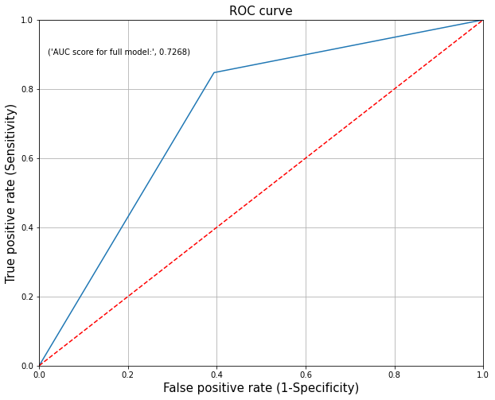

```python
plt.figure(figsize=(10,8))
fpr, tpr, thresholds = roc_curve(y_train_res,y_train_prob)
plt.plot(fpr,tpr)

plt.xlim([0.0,1.0])
plt.ylim([0.0,1.0])

plt.plot([0,1],[0,1],'r--')

plt.title('ROC curve', fontsize = 15)
plt.xlabel('False positive rate (1-Specificity)', fontsize = 15)
plt.ylabel('True positive rate (Sensitivity)', fontsize = 15)

plt.text(x=0.02,y=0.9,s=('AUC score for full model:',round(metrics.roc_auc_score(y_train_res,y_train_prob),4)))


plt.grid(True)
```

##### For Test

```python
# predict target values using model built
y_test_prob = dt_tuned_model.predict(x_best_test)

y_test_pred = [0 if x<0.5 else 1 for x in y_test_prob]

# display the classification report
print(classification_report(y_test,y_test_pred))
```

```
              precision    recall  f1-score   support

           0       0.88      0.62      0.73       996
           1       0.46      0.79      0.58       411

    accuracy                           0.67      1407
   macro avg       0.67      0.70      0.66      1407
weighted avg       0.76      0.67      0.69      1407
```

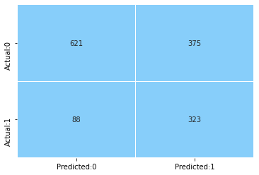

```python
cm = confusion_matrix(y_test,y_test_pred)
con_matrix = pd.DataFrame(cm,columns=['Predicted:0','Predicted:1'],index=['Actual:0','Actual:1'])
sns.heatmap(con_matrix,annot=True,fmt='d',cmap=ListedColormap(['Lightskyblue']),cbar=False,linewidths=0.1)
plt.show()
```

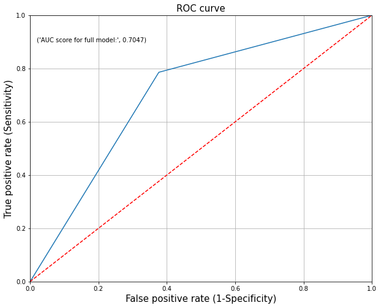

```python
plt.figure(figsize=(10,8))
fpr, tpr, thresholds = roc_curve(y_test,y_test_prob)
plt.plot(fpr,tpr)

plt.xlim([0.0,1.0])
plt.ylim([0.0,1.0])

plt.plot([0,1],[0,1],'r--')

plt.title('ROC curve', fontsize = 15)
plt.xlabel('False positive rate (1-Specificity)', fontsize = 15)
plt.ylabel('True positive rate (Sensitivity)', fontsize = 15)

plt.text(x=0.02,y=0.9,s=('AUC score for full model:',round(metrics.roc_auc_score(y_test,y_test_prob),4)))


plt.grid(True)
```

```python
Performance_report(dt_tuned_model, 'Tuned Decision Tree on Best Features')
report_card
```

|  | Model Name | AUC Score | Precision Score | Recall Score | Accuracy Score | Kappa Score | f1-score |
| --- | --- | --- | --- | --- | --- | --- | --- |
| 0 | Basic Decision Tree | 0.663973 | 0.541885 | 0.503650 | 0.730633 | 0.334886 | 0.522068 |
| 1 | Tuned Decision Tree | 0.708652 | 0.706485 | 0.503650 | 0.793888 | 0.455729 | 0.588068 |
| 2 | Basic RandomForest Tree | 0.692837 | 0.692857 | 0.472019 | 0.784648 | 0.425503 | 0.561505 |
| 3 | Basic KNN Tree | 0.655476 | 0.549858 | 0.469586 | 0.732765 | 0.324880 | 0.506562 |
| 4 | Tuned Random Forest Tree | 0.675630 | 0.767442 | 0.401460 | 0.789623 | 0.408464 | 0.527157 |
| 5 | Tuned KNN Tree | 0.718850 | 0.658046 | 0.557178 | 0.786070 | 0.458332 | 0.603426 |
| 6 | Basic Navie Bayes Tree | 0.769256 | 0.581181 | 0.766423 | 0.770434 | 0.492419 | 0.661070 |
| 7 | Ada Boosting | 0.726611 | 0.714744 | 0.542579 | 0.803127 | 0.487723 | 0.616874 |
| 8 | Tuned Ada Boost | 0.716472 | 0.751825 | 0.501217 | 0.805970 | 0.479924 | 0.601460 |
| 9 | Gadient Boosting | 0.703343 | 0.677524 | 0.506083 | 0.785359 | 0.439333 | 0.579387 |
| 10 | XGBoost model | 0.720085 | 0.686154 | 0.542579 | 0.793888 | 0.468989 | 0.605978 |
| 11 | Tunned XGBoost | 0.721899 | 0.731293 | 0.523114 | 0.804549 | 0.484284 | 0.609929 |
| 12 | Decision Tree with Best Features | 0.691917 | 0.538631 | 0.593674 | 0.732765 | 0.372651 | 0.564815 |
| 13 | Tuned Decision Tree on Best Features | 0.704691 | 0.462751 | 0.785888 | 0.670931 | 0.339716 | 0.582507 |

## Random Forest

|  | **import libraries** |
| --- | --- |

```python
from sklearn.ensemble import RandomForestClassifier
```

```python
#instantiate RandomForestClassifier
# chosing random state value as 10
rf = RandomForestClassifier(random_state = 10)

# fit the model using train data set
rf_model = rf.fit(x_best_train,y_train_res)
```

##### For Train

```python
# predict target values using model built on train data
y_train_prob = rf_model.predict(x_best_train)

y_train_pred = [0 if x<0.5 else 1 for x in y_train_prob]

# display the classification report
print(classification_report(y_train_res,y_train_pred))
```

```
              precision    recall  f1-score   support

           0       1.00      1.00      1.00      4167
           1       1.00      1.00      1.00      4167

    accuracy                           1.00      8334
   macro avg       1.00      1.00      1.00      8334
weighted avg       1.00      1.00      1.00      8334
```

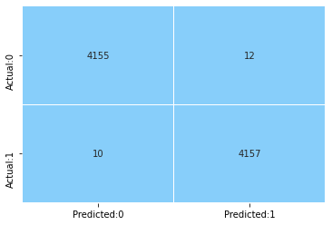

```python
cm = confusion_matrix(y_train_res,y_train_pred)
con_matrix = pd.DataFrame(cm,columns=['Predicted:0','Predicted:1'],index=['Actual:0','Actual:1'])
sns.heatmap(con_matrix,annot=True,fmt='d',cmap=ListedColormap(['Lightskyblue']),cbar=False,linewidths=0.1)
plt.show()
```

##### For Test

```python
# predict target values using model built on test data
y_test_prob = rf_model.predict(x_best_test)

y_test_pred = [0 if x<0.5 else 1 for x in y_test_prob]

# display the classification report
print(classification_report(y_test,y_test_pred))
```

```
              precision    recall  f1-score   support

           0       0.83      0.84      0.84       996
           1       0.61      0.59      0.60       411

    accuracy                           0.77      1407
   macro avg       0.72      0.72      0.72      1407
weighted avg       0.77      0.77      0.77      1407
```

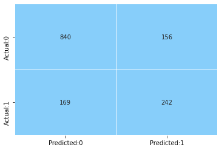

```python
cm = confusion_matrix(y_test,y_test_pred)
con_matrix = pd.DataFrame(cm,columns=['Predicted:0','Predicted:1'],index=['Actual:0','Actual:1'])
sns.heatmap(con_matrix,annot=True,fmt='d',cmap=ListedColormap(['Lightskyblue']),cbar=False,linewidths=0.1)
plt.show()
```

```python
Performance_report(rf_model, 'Random Forest with best features')
report_card
```

|  | Model Name | AUC Score | Precision Score | Recall Score | Accuracy Score | Kappa Score | f1-score |
| --- | --- | --- | --- | --- | --- | --- | --- |
| 0 | Basic Decision Tree | 0.663973 | 0.541885 | 0.503650 | 0.730633 | 0.334886 | 0.522068 |
| 1 | Tuned Decision Tree | 0.708652 | 0.706485 | 0.503650 | 0.793888 | 0.455729 | 0.588068 |
| 2 | Basic RandomForest Tree | 0.692837 | 0.692857 | 0.472019 | 0.784648 | 0.425503 | 0.561505 |
| 3 | Basic KNN Tree | 0.655476 | 0.549858 | 0.469586 | 0.732765 | 0.324880 | 0.506562 |
| 4 | Tuned Random Forest Tree | 0.675630 | 0.767442 | 0.401460 | 0.789623 | 0.408464 | 0.527157 |
| 5 | Tuned KNN Tree | 0.718850 | 0.658046 | 0.557178 | 0.786070 | 0.458332 | 0.603426 |
| 6 | Basic Navie Bayes Tree | 0.769256 | 0.581181 | 0.766423 | 0.770434 | 0.492419 | 0.661070 |
| 7 | Ada Boosting | 0.726611 | 0.714744 | 0.542579 | 0.803127 | 0.487723 | 0.616874 |
| 8 | Tuned Ada Boost | 0.716472 | 0.751825 | 0.501217 | 0.805970 | 0.479924 | 0.601460 |
| 9 | Gadient Boosting | 0.703343 | 0.677524 | 0.506083 | 0.785359 | 0.439333 | 0.579387 |
| 10 | XGBoost model | 0.720085 | 0.686154 | 0.542579 | 0.793888 | 0.468989 | 0.605978 |
| 11 | Tunned XGBoost | 0.721899 | 0.731293 | 0.523114 | 0.804549 | 0.484284 | 0.609929 |
| 12 | Decision Tree with Best Features | 0.691917 | 0.538631 | 0.593674 | 0.732765 | 0.372651 | 0.564815 |
| 13 | Tuned Decision Tree on Best Features | 0.704691 | 0.462751 | 0.785888 | 0.670931 | 0.339716 | 0.582507 |
| 14 | Random Forest with best features | 0.716091 | 0.608040 | 0.588808 | 0.769012 | 0.436233 | 0.598269 |

## Hyper Parameter Tuning for Random Forest

```python
tuned_paramaters_rf = [{'criterion': ['entropy', 'gini'],
                     'n_estimators': [10, 30, 50, 70, 90],
                     'max_depth': [10, 15, 20],
                     'max_features': ['sqrt', 'log2'],
                     'min_samples_split': [2, 5, 8, 11],
                     'min_samples_leaf': [1, 5, 9],
                     'max_leaf_nodes': [2, 5, 8, 11]}]
```

```python
RF = RandomForestClassifier()
gscv_rf = GridSearchCV(estimator=RF, param_grid=tuned_paramaters_rf, cv=5)
gscv_rf_model = gscv_rf.fit(x_best_train,y_train_res)
gscv_rf_model.best_params_
```

```
{'criterion': 'gini',
 'max_depth': 20,
 'max_features': 'sqrt',
 'max_leaf_nodes': 11,
 'min_samples_leaf': 1,
 'min_samples_split': 11,
 'n_estimators': 70}
```

```python
rf_tuned = RandomForestClassifier(n_estimators=70, criterion='gini', max_depth=15, max_features='log2', max_leaf_nodes=11, min_samples_leaf=9, min_samples_split=11)
rf_tuned_model = rf_tuned.fit(x_best_train,y_train_res)
```

##### For Train

```python
# predict target values using model built on train data
y_train_prob = rf_tuned_model.predict(x_best_train)

y_train_pred = [0 if x<0.5 else 1 for x in y_train_prob]

# display the classification report
print(classification_report(y_train_res,y_train_pred))
```

```
              precision    recall  f1-score   support

           0       0.80      0.76      0.78      4167
           1       0.77      0.81      0.79      4167

    accuracy                           0.79      8334
   macro avg       0.79      0.79      0.79      8334
weighted avg       0.79      0.79      0.79      8334
```

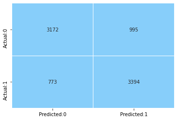

```python
cm = confusion_matrix(y_train_res,y_train_pred)
con_matrix = pd.DataFrame(cm,columns=['Predicted:0','Predicted:1'],index=['Actual:0','Actual:1'])
sns.heatmap(con_matrix,annot=True,fmt='d',cmap=ListedColormap(['Lightskyblue']),cbar=False,linewidths=0.1)
plt.show()
```

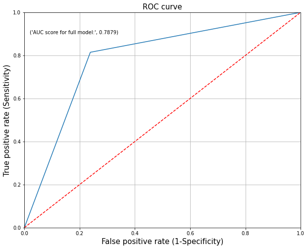

```python
plt.figure(figsize=(10,8))
fpr, tpr, thresholds = roc_curve(y_train_res,y_train_prob)
plt.plot(fpr,tpr)

plt.xlim([0.0,1.0])
plt.ylim([0.0,1.0])

plt.plot([0,1],[0,1],'r--')

plt.title('ROC curve', fontsize = 15)
plt.xlabel('False positive rate (1-Specificity)', fontsize = 15)
plt.ylabel('True positive rate (Sensitivity)', fontsize = 15)

plt.text(x=0.02,y=0.9,s=('AUC score for full model:',round(metrics.roc_auc_score(y_train_res,y_train_prob),4)))


plt.grid(True)
```

##### For Test

```python
# predict target values using model built on test data
y_test_prob = rf_tuned_model.predict(x_best_test)

y_test_pred = [0 if x<0.5 else 1 for x in y_test_prob]

# display the classification report
print(classification_report(y_test,y_test_pred))
```

```
              precision    recall  f1-score   support

           0       0.88      0.78      0.83       996
           1       0.59      0.75      0.66       411

    accuracy                           0.77      1407
   macro avg       0.73      0.77      0.74      1407
weighted avg       0.80      0.77      0.78      1407
```

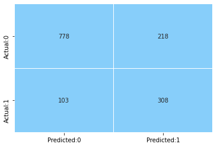

```python
cm = confusion_matrix(y_test,y_test_pred)
con_matrix = pd.DataFrame(cm,columns=['Predicted:0','Predicted:1'],index=['Actual:0','Actual:1'])
sns.heatmap(con_matrix,annot=True,fmt='d',cmap=ListedColormap(['Lightskyblue']),cbar=False,linewidths=0.1)
plt.show()
```

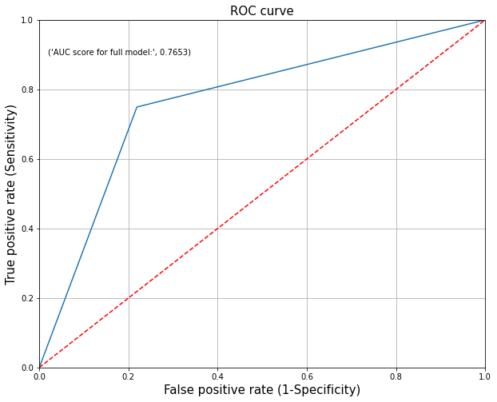

```python
plt.figure(figsize=(10,8))
fpr, tpr, thresholds = roc_curve(y_test,y_test_prob)
plt.plot(fpr,tpr)

plt.xlim([0.0,1.0])
plt.ylim([0.0,1.0])

plt.plot([0,1],[0,1],'r--')

plt.title('ROC curve', fontsize = 15)
plt.xlabel('False positive rate (1-Specificity)', fontsize = 15)
plt.ylabel('True positive rate (Sensitivity)', fontsize = 15)

plt.text(x=0.02,y=0.9,s=('AUC score for full model:',round(metrics.roc_auc_score(y_test,y_test_prob),4)))


plt.grid(True)
```

```python
Performance_report(rf_tuned_model, 'Tunned RandomForest with Best features')
report_card
```

|  | Model Name | AUC Score | Precision Score | Recall Score | Accuracy Score | Kappa Score | f1-score |
| --- | --- | --- | --- | --- | --- | --- | --- |
| 0 | Basic Decision Tree | 0.663973 | 0.541885 | 0.503650 | 0.730633 | 0.334886 | 0.522068 |
| 1 | Tuned Decision Tree | 0.708652 | 0.706485 | 0.503650 | 0.793888 | 0.455729 | 0.588068 |
| 2 | Basic RandomForest Tree | 0.692837 | 0.692857 | 0.472019 | 0.784648 | 0.425503 | 0.561505 |
| 3 | Basic KNN Tree | 0.655476 | 0.549858 | 0.469586 | 0.732765 | 0.324880 | 0.506562 |
| 4 | Tuned Random Forest Tree | 0.675630 | 0.767442 | 0.401460 | 0.789623 | 0.408464 | 0.527157 |
| 5 | Tuned KNN Tree | 0.718850 | 0.658046 | 0.557178 | 0.786070 | 0.458332 | 0.603426 |
| 6 | Basic Navie Bayes Tree | 0.769256 | 0.581181 | 0.766423 | 0.770434 | 0.492419 | 0.661070 |
| 7 | Ada Boosting | 0.726611 | 0.714744 | 0.542579 | 0.803127 | 0.487723 | 0.616874 |
| 8 | Tuned Ada Boost | 0.716472 | 0.751825 | 0.501217 | 0.805970 | 0.479924 | 0.601460 |
| 9 | Gadient Boosting | 0.703343 | 0.677524 | 0.506083 | 0.785359 | 0.439333 | 0.579387 |
| 10 | XGBoost model | 0.720085 | 0.686154 | 0.542579 | 0.793888 | 0.468989 | 0.605978 |
| 11 | Tunned XGBoost | 0.721899 | 0.731293 | 0.523114 | 0.804549 | 0.484284 | 0.609929 |
| 12 | Decision Tree with Best Features | 0.691917 | 0.538631 | 0.593674 | 0.732765 | 0.372651 | 0.564815 |
| 13 | Tuned Decision Tree on Best Features | 0.704691 | 0.462751 | 0.785888 | 0.670931 | 0.339716 | 0.582507 |
| 14 | Random Forest with best features | 0.716091 | 0.608040 | 0.588808 | 0.769012 | 0.436233 | 0.598269 |
| 15 | Tunned RandomForest with Best features | 0.765258 | 0.585551 | 0.749392 | 0.771855 | 0.490233 | 0.657417 |

## Naive Bayes

|  | **import libraries** |
| --- | --- |

```python
from sklearn.naive_bayes import GaussianNB
```

```python
gnb = GaussianNB()
nb_model = gnb.fit(x_best_train, y_train_res)
```

##### For Train

```python
y_train_pred = nb_model.predict(x_best_train)
print(classification_report(y_train_res,y_train_pred))
```

```
              precision    recall  f1-score   support

           0       0.80      0.69      0.74      4167
           1       0.73      0.83      0.78      4167

    accuracy                           0.76      8334
   macro avg       0.77      0.76      0.76      8334
weighted avg       0.77      0.76      0.76      8334
```

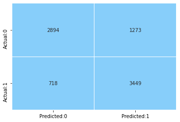

```python
cm = confusion_matrix(y_train_res,y_train_pred)
con_matrix = pd.DataFrame(cm,columns=['Predicted:0','Predicted:1'],index=['Actual:0','Actual:1'])
sns.heatmap(con_matrix,annot=True,fmt='d',cmap=ListedColormap(['Lightskyblue']),cbar=False,linewidths=0.1)
plt.show()
```

```python
y_train_proba = nb_model.predict_proba(x_best_train)
y_train_prob = pd.DataFrame(y_train_proba, columns=[1, 2])
y_train_proba = y_train_prob[2]
```

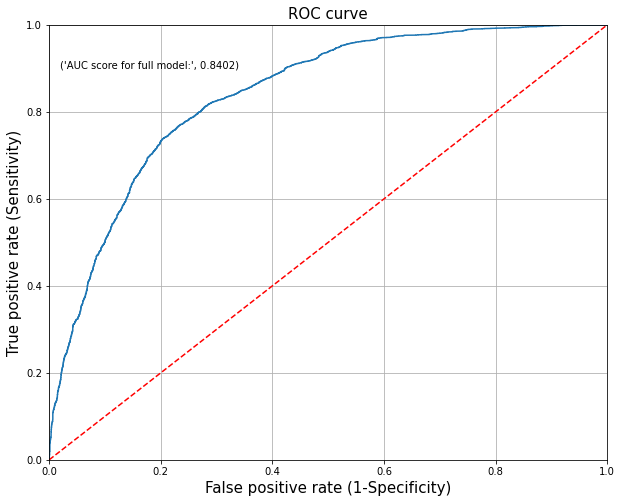

```python
plt.figure(figsize=(10,8))
fpr, tpr, thresholds = roc_curve(y_train_res,y_train_proba)
plt.plot(fpr,tpr)

plt.xlim([0.0,1.0])
plt.ylim([0.0,1.0])

plt.plot([0,1],[0,1],'r--')

plt.title('ROC curve', fontsize = 15)
plt.xlabel('False positive rate (1-Specificity)', fontsize = 15)
plt.ylabel('True positive rate (Sensitivity)', fontsize = 15)

plt.text(x=0.02,y=0.9,s=('AUC score for full model:',round(metrics.roc_auc_score(y_train_res,y_train_proba),4)))


plt.grid(True)
```

##### For Test

```python
y_test_pred = nb_model.predict(x_best_test)
print(classification_report(y_test,y_test_pred))
```

```
              precision    recall  f1-score   support

           0       0.89      0.73      0.80       996
           1       0.54      0.79      0.64       411

    accuracy                           0.74      1407
   macro avg       0.72      0.76      0.72      1407
weighted avg       0.79      0.74      0.76      1407
```

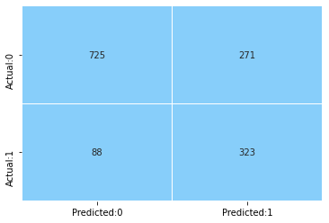

```python
cm = confusion_matrix(y_test,y_test_pred)
con_matrix = pd.DataFrame(cm,columns=['Predicted:0','Predicted:1'],index=['Actual:0','Actual:1'])
sns.heatmap(con_matrix,annot=True,fmt='d',cmap=ListedColormap(['Lightskyblue']),cbar=False,linewidths=0.1)
plt.show()
```

```python
y_test_proba = nb_model.predict_proba(x_best_test)
y_test_prob = pd.DataFrame(y_test_proba, columns=[1, 2])
y_test_proba = y_test_prob[2]
```

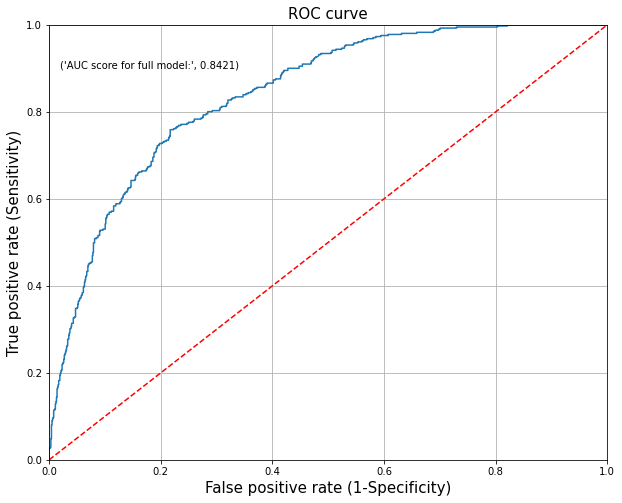

```python
plt.figure(figsize=(10,8))
fpr, tpr, thresholds = roc_curve(y_test,y_test_proba)
plt.plot(fpr,tpr)

plt.xlim([0.0,1.0])
plt.ylim([0.0,1.0])

plt.plot([0,1],[0,1],'r--')

plt.title('ROC curve', fontsize = 15)
plt.xlabel('False positive rate (1-Specificity)', fontsize = 15)
plt.ylabel('True positive rate (Sensitivity)', fontsize = 15)

plt.text(x=0.02,y=0.9,s=('AUC score for full model:',round(metrics.roc_auc_score(y_test,y_test_proba),4)))


plt.grid(True)
```

```python
Performance_report(nb_model, 'Navie bayes with Best features')
report_card
```

|  | Model Name | AUC Score | Precision Score | Recall Score | Accuracy Score | Kappa Score | f1-score |
| --- | --- | --- | --- | --- | --- | --- | --- |
| 0 | Basic Decision Tree | 0.663973 | 0.541885 | 0.503650 | 0.730633 | 0.334886 | 0.522068 |
| 1 | Tuned Decision Tree | 0.708652 | 0.706485 | 0.503650 | 0.793888 | 0.455729 | 0.588068 |
| 2 | Basic RandomForest Tree | 0.692837 | 0.692857 | 0.472019 | 0.784648 | 0.425503 | 0.561505 |
| 3 | Basic KNN Tree | 0.655476 | 0.549858 | 0.469586 | 0.732765 | 0.324880 | 0.506562 |
| 4 | Tuned Random Forest Tree | 0.675630 | 0.767442 | 0.401460 | 0.789623 | 0.408464 | 0.527157 |
| 5 | Tuned KNN Tree | 0.718850 | 0.658046 | 0.557178 | 0.786070 | 0.458332 | 0.603426 |
| 6 | Basic Navie Bayes Tree | 0.769256 | 0.581181 | 0.766423 | 0.770434 | 0.492419 | 0.661070 |
| 7 | Ada Boosting | 0.726611 | 0.714744 | 0.542579 | 0.803127 | 0.487723 | 0.616874 |
| 8 | Tuned Ada Boost | 0.716472 | 0.751825 | 0.501217 | 0.805970 | 0.479924 | 0.601460 |
| 9 | Gadient Boosting | 0.703343 | 0.677524 | 0.506083 | 0.785359 | 0.439333 | 0.579387 |
| 10 | XGBoost model | 0.720085 | 0.686154 | 0.542579 | 0.793888 | 0.468989 | 0.605978 |
| 11 | Tunned XGBoost | 0.721899 | 0.731293 | 0.523114 | 0.804549 | 0.484284 | 0.609929 |
| 12 | Decision Tree with Best Features | 0.691917 | 0.538631 | 0.593674 | 0.732765 | 0.372651 | 0.564815 |
| 13 | Tuned Decision Tree on Best Features | 0.704691 | 0.462751 | 0.785888 | 0.670931 | 0.339716 | 0.582507 |
| 14 | Random Forest with best features | 0.716091 | 0.608040 | 0.588808 | 0.769012 | 0.436233 | 0.598269 |
| 15 | Tunned RandomForest with Best features | 0.765258 | 0.585551 | 0.749392 | 0.771855 | 0.490233 | 0.657417 |
| 16 | Navie bayes with Best features | 0.756900 | 0.543771 | 0.785888 | 0.744847 | 0.454384 | 0.642786 |

## Stacking

|  | **import libraries** |
| --- | --- |

```python
from sklearn.ensemble import StackingClassifier
from sklearn.ensemble import AdaBoostClassifier, GradientBoostingClassifier
```

```python
estimators = [
    ('rf', RandomForestClassifier(n_estimators=30, random_state=42)),
    ('nb', GaussianNB())
]
clf = StackingClassifier(
    estimators=estimators, final_estimator=LogisticRegression()
    )
```

```python
stack_model = clf.fit(x_best_train, y_train_res)
```

##### For Train

```python
y_train_pred = stack_model.predict(x_best_train)
print(classification_report(y_train_res,y_train_pred))
```

```
              precision    recall  f1-score   support

           0       0.99      0.99      0.99      4167
           1       0.99      0.99      0.99      4167

    accuracy                           0.99      8334
   macro avg       0.99      0.99      0.99      8334
weighted avg       0.99      0.99      0.99      8334
```

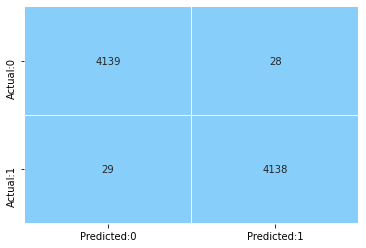

```python
cm = confusion_matrix(y_train_res,y_train_pred)
con_matrix = pd.DataFrame(cm,columns=['Predicted:0','Predicted:1'],index=['Actual:0','Actual:1'])
sns.heatmap(con_matrix,annot=True,fmt='d',cmap=ListedColormap(['Lightskyblue']),cbar=False,linewidths=0.1)
plt.show()
```

##### For Test

```python
y_test_pred = stack_model.predict(x_best_test)
print(classification_report(y_test,y_test_pred))
```

```
              precision    recall  f1-score   support

           0       0.84      0.83      0.83       996
           1       0.60      0.61      0.60       411

    accuracy                           0.76      1407
   macro avg       0.72      0.72      0.72      1407
weighted avg       0.77      0.76      0.77      1407
```

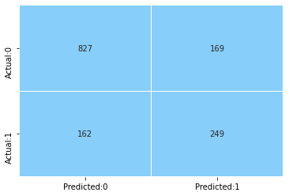

```python
cm = confusion_matrix(y_test,y_test_pred)
con_matrix = pd.DataFrame(cm,columns=['Predicted:0','Predicted:1'],index=['Actual:0','Actual:1'])
sns.heatmap(con_matrix,annot=True,fmt='d',cmap=ListedColormap(['Lightskyblue']),cbar=False,linewidths=0.1)
plt.show()
```

```python
Performance_report(stack_model, 'Stacked Model')
report_card
```

|  | Model Name | AUC Score | Precision Score | Recall Score | Accuracy Score | Kappa Score | f1-score |
| --- | --- | --- | --- | --- | --- | --- | --- |
| 0 | Basic Decision Tree | 0.663973 | 0.541885 | 0.503650 | 0.730633 | 0.334886 | 0.522068 |
| 1 | Tuned Decision Tree | 0.708652 | 0.706485 | 0.503650 | 0.793888 | 0.455729 | 0.588068 |
| 2 | Basic RandomForest Tree | 0.692837 | 0.692857 | 0.472019 | 0.784648 | 0.425503 | 0.561505 |
| 3 | Basic KNN Tree | 0.655476 | 0.549858 | 0.469586 | 0.732765 | 0.324880 | 0.506562 |
| 4 | Tuned Random Forest Tree | 0.675630 | 0.767442 | 0.401460 | 0.789623 | 0.408464 | 0.527157 |
| 5 | Tuned KNN Tree | 0.718850 | 0.658046 | 0.557178 | 0.786070 | 0.458332 | 0.603426 |
| 6 | Basic Navie Bayes Tree | 0.769256 | 0.581181 | 0.766423 | 0.770434 | 0.492419 | 0.661070 |
| 7 | Ada Boosting | 0.726611 | 0.714744 | 0.542579 | 0.803127 | 0.487723 | 0.616874 |
| 8 | Tuned Ada Boost | 0.716472 | 0.751825 | 0.501217 | 0.805970 | 0.479924 | 0.601460 |
| 9 | Gadient Boosting | 0.703343 | 0.677524 | 0.506083 | 0.785359 | 0.439333 | 0.579387 |
| 10 | XGBoost model | 0.720085 | 0.686154 | 0.542579 | 0.793888 | 0.468989 | 0.605978 |
| 11 | Tunned XGBoost | 0.721899 | 0.731293 | 0.523114 | 0.804549 | 0.484284 | 0.609929 |
| 12 | Decision Tree with Best Features | 0.691917 | 0.538631 | 0.593674 | 0.732765 | 0.372651 | 0.564815 |
| 13 | Tuned Decision Tree on Best Features | 0.704691 | 0.462751 | 0.785888 | 0.670931 | 0.339716 | 0.582507 |
| 14 | Random Forest with best features | 0.716091 | 0.608040 | 0.588808 | 0.769012 | 0.436233 | 0.598269 |
| 15 | Tunned RandomForest with Best features | 0.765258 | 0.585551 | 0.749392 | 0.771855 | 0.490233 | 0.657417 |
| 16 | Navie bayes with Best features | 0.756900 | 0.543771 | 0.785888 | 0.744847 | 0.454384 | 0.642786 |
| 17 | Stacked Model | 0.718080 | 0.595694 | 0.605839 | 0.764748 | 0.433990 | 0.600724 |

## XGboost

```python
import xgboost

xgb = xgboost.XGBClassifier(max_depth = 10, gamma = 1)

xgb_model = xgb.fit(x_best_train, y_train_res)
```

[output not shown]

##### For Train

```python
y_train_pred = xgb_model.predict(x_best_train)
print(classification_report(y_train_res,y_train_pred))
```

```
              precision    recall  f1-score   support

           0       0.97      0.94      0.95      4167
           1       0.94      0.97      0.95      4167

    accuracy                           0.95      8334
   macro avg       0.95      0.95      0.95      8334
weighted avg       0.95      0.95      0.95      8334
```

##### For Test

```python
y_test_pred = xgb_model.predict(x_best_test)
print(classification_report(y_test,y_test_pred))
```

```
              precision    recall  f1-score   support

           0       0.83      0.85      0.84       996
           1       0.61      0.59      0.60       411

    accuracy                           0.77      1407
   macro avg       0.72      0.72      0.72      1407
weighted avg       0.77      0.77      0.77      1407
```

```python
Performance_report(xgb_model, 'XGBoost')
report_card
```

|  | Model Name | AUC Score | Precision Score | Recall Score | Accuracy Score | Kappa Score | f1-score |
| --- | --- | --- | --- | --- | --- | --- | --- |
| 0 | Basic Decision Tree | 0.663973 | 0.541885 | 0.503650 | 0.730633 | 0.334886 | 0.522068 |
| 1 | Tuned Decision Tree | 0.708652 | 0.706485 | 0.503650 | 0.793888 | 0.455729 | 0.588068 |
| 2 | Basic RandomForest Tree | 0.692837 | 0.692857 | 0.472019 | 0.784648 | 0.425503 | 0.561505 |
| 3 | Basic KNN Tree | 0.655476 | 0.549858 | 0.469586 | 0.732765 | 0.324880 | 0.506562 |
| 4 | Tuned Random Forest Tree | 0.675630 | 0.767442 | 0.401460 | 0.789623 | 0.408464 | 0.527157 |
| 5 | Tuned KNN Tree | 0.718850 | 0.658046 | 0.557178 | 0.786070 | 0.458332 | 0.603426 |
| 6 | Basic Navie Bayes Tree | 0.769256 | 0.581181 | 0.766423 | 0.770434 | 0.492419 | 0.661070 |
| 7 | Ada Boosting | 0.726611 | 0.714744 | 0.542579 | 0.803127 | 0.487723 | 0.616874 |
| 8 | Tuned Ada Boost | 0.716472 | 0.751825 | 0.501217 | 0.805970 | 0.479924 | 0.601460 |
| 9 | Gadient Boosting | 0.703343 | 0.677524 | 0.506083 | 0.785359 | 0.439333 | 0.579387 |
| 10 | XGBoost model | 0.720085 | 0.686154 | 0.542579 | 0.793888 | 0.468989 | 0.605978 |
| 11 | Tunned XGBoost | 0.721899 | 0.731293 | 0.523114 | 0.804549 | 0.484284 | 0.609929 |
| 12 | Decision Tree with Best Features | 0.691917 | 0.538631 | 0.593674 | 0.732765 | 0.372651 | 0.564815 |
| 13 | Tuned Decision Tree on Best Features | 0.704691 | 0.462751 | 0.785888 | 0.670931 | 0.339716 | 0.582507 |
| 14 | Random Forest with best features | 0.716091 | 0.608040 | 0.588808 | 0.769012 | 0.436233 | 0.598269 |
| 15 | Tunned RandomForest with Best features | 0.765258 | 0.585551 | 0.749392 | 0.771855 | 0.490233 | 0.657417 |
| 16 | Navie bayes with Best features | 0.756900 | 0.543771 | 0.785888 | 0.744847 | 0.454384 | 0.642786 |
| 17 | Stacked Model | 0.718080 | 0.595694 | 0.605839 | 0.764748 | 0.433990 | 0.600724 |
| 18 | XGBoost | 0.718311 | 0.612091 | 0.591241 | 0.771144 | 0.441034 | 0.601485 |

## HyperParameter Tuning for XGboost

```python
tuning_parameters = {'learning_rate': [0.1, 0.2, 0.3, 0.4, 0.5, 0.6],
                     'max_depth': range(3,10),
                     'gamma': [0, 1, 2, 3, 4]}

# instantiate the 'XGBClassifier'
xgb_mod = xgboost.XGBClassifier()

xgb_grid = GridSearchCV(estimator = xgb_mod, param_grid = tuning_parameters, cv = 3, scoring = 'roc_auc')

# fit the model on X_train and y_train using fit()
xgb_grid.fit(X_train, y_train)

# get the best parameters
print('Best parameters for XGBoost classifier: ', xgb_grid.best_params_, '\n')
```

[output not shown]

[output cut: 615 more lines]

```python
xgb_tuned = xgboost.XGBClassifier(gamma = 2, learning_rate = 0.1, max_depth = 4)
xgb_model_tuned = xgb_tuned.fit(x_best_train, y_train_res)
```

[output not shown]

```python
y_train_pred = xgb_model_tuned.predict(x_best_train)
print(classification_report(y_train_res,y_train_pred))
```

```
              precision    recall  f1-score   support

           0       0.86      0.82      0.84      4167
           1       0.83      0.87      0.85      4167

    accuracy                           0.84      8334
   macro avg       0.84      0.84      0.84      8334
weighted avg       0.84      0.84      0.84      8334
```

```python
y_train_proba = xgb_model_tuned.predict_proba(x_best_train)
y_train_prob = pd.DataFrame(y_train_proba, columns=[1, 2])
y_train_proba = y_train_prob[2]
```

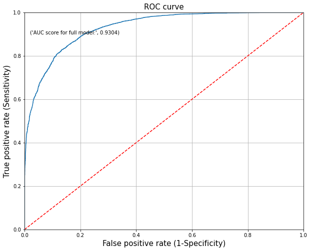

```python
plt.figure(figsize=(10,8))
fpr, tpr, thresholds = roc_curve(y_train_res,y_train_proba)
plt.plot(fpr,tpr)

plt.xlim([0.0,1.0])
plt.ylim([0.0,1.0])

plt.plot([0,1],[0,1],'r--')

plt.title('ROC curve', fontsize = 15)
plt.xlabel('False positive rate (1-Specificity)', fontsize = 15)
plt.ylabel('True positive rate (Sensitivity)', fontsize = 15)

plt.text(x=0.02,y=0.9,s=('AUC score for full model:',round(metrics.roc_auc_score(y_train_res,y_train_proba),4)))


plt.grid(True)
```

```python
y_test_pred = xgb_model_tuned.predict(x_best_test)
print(classification_report(y_test,y_test_pred))
```

```
              precision    recall  f1-score   support

           0       0.87      0.83      0.85       996
           1       0.63      0.70      0.67       411

    accuracy                           0.79      1407
   macro avg       0.75      0.77      0.76      1407
weighted avg       0.80      0.79      0.80      1407
```

```python
y_test_proba = xgb_model_tuned.predict_proba(x_best_test)
y_test_prob = pd.DataFrame(y_test_proba, columns=[1, 2])
y_test_proba = y_test_prob[2]
```

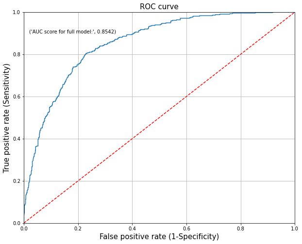

```python
plt.figure(figsize=(10,8))
fpr, tpr, thresholds = roc_curve(y_test,y_test_proba)
plt.plot(fpr,tpr)

plt.xlim([0.0,1.0])
plt.ylim([0.0,1.0])

plt.plot([0,1],[0,1],'r--')

plt.title('ROC curve', fontsize = 15)
plt.xlabel('False positive rate (1-Specificity)', fontsize = 15)
plt.ylabel('True positive rate (Sensitivity)', fontsize = 15)

plt.text(x=0.02,y=0.9,s=('AUC score for full model:',round(metrics.roc_auc_score(y_test,y_test_proba),4)))


plt.grid(True)
```

```python
Performance_report(xgb_model_tuned, 'Tunned XGBoost with best features')
report_card
```

|  | Model Name | AUC Score | Precision Score | Recall Score | Accuracy Score | Kappa Score | f1-score |
| --- | --- | --- | --- | --- | --- | --- | --- |
| 0 | Basic Decision Tree | 0.663973 | 0.541885 | 0.503650 | 0.730633 | 0.334886 | 0.522068 |
| 1 | Tuned Decision Tree | 0.708652 | 0.706485 | 0.503650 | 0.793888 | 0.455729 | 0.588068 |
| 2 | Basic RandomForest Tree | 0.692837 | 0.692857 | 0.472019 | 0.784648 | 0.425503 | 0.561505 |
| 3 | Basic KNN Tree | 0.655476 | 0.549858 | 0.469586 | 0.732765 | 0.324880 | 0.506562 |
| 4 | Tuned Random Forest Tree | 0.675630 | 0.767442 | 0.401460 | 0.789623 | 0.408464 | 0.527157 |
| 5 | Tuned KNN Tree | 0.718850 | 0.658046 | 0.557178 | 0.786070 | 0.458332 | 0.603426 |
| 6 | Basic Navie Bayes Tree | 0.769256 | 0.581181 | 0.766423 | 0.770434 | 0.492419 | 0.661070 |
| 7 | Ada Boosting | 0.726611 | 0.714744 | 0.542579 | 0.803127 | 0.487723 | 0.616874 |
| 8 | Tuned Ada Boost | 0.716472 | 0.751825 | 0.501217 | 0.805970 | 0.479924 | 0.601460 |
| 9 | Gadient Boosting | 0.703343 | 0.677524 | 0.506083 | 0.785359 | 0.439333 | 0.579387 |
| 10 | XGBoost model | 0.720085 | 0.686154 | 0.542579 | 0.793888 | 0.468989 | 0.605978 |
| 11 | Tunned XGBoost | 0.721899 | 0.731293 | 0.523114 | 0.804549 | 0.484284 | 0.609929 |
| 12 | Decision Tree with Best Features | 0.691917 | 0.538631 | 0.593674 | 0.732765 | 0.372651 | 0.564815 |
| 13 | Tuned Decision Tree on Best Features | 0.704691 | 0.462751 | 0.785888 | 0.670931 | 0.339716 | 0.582507 |
| 14 | Random Forest with best features | 0.716091 | 0.608040 | 0.588808 | 0.769012 | 0.436233 | 0.598269 |
| 15 | Tunned RandomForest with Best features | 0.765258 | 0.585551 | 0.749392 | 0.771855 | 0.490233 | 0.657417 |
| 16 | Navie bayes with Best features | 0.756900 | 0.543771 | 0.785888 | 0.744847 | 0.454384 | 0.642786 |
| 17 | Stacked Model | 0.718080 | 0.595694 | 0.605839 | 0.764748 | 0.433990 | 0.600724 |
| 18 | XGBoost | 0.718311 | 0.612091 | 0.591241 | 0.771144 | 0.441034 | 0.601485 |
| 19 | Tunned XGBoost with best features | 0.766742 | 0.631004 | 0.703163 | 0.793177 | 0.516150 | 0.665132 |